# Light Cue Manuscript Statistics Overview

Brandon Güell

11/11/2017

> The statistical analysis shown here are from the Güell & Warkentin light cue manuscript Analysis are shows in chronological order as reported in the manuscript. I show details on importing, manipulating, summarizing, analyzing, and visualizing the data. See manuscript for details on background, research questions, hypothesis, methods, etc.

# Hatching Timing Experiment Data Analysis

## Data importing

First, we can load the data straight from my computer as follows…

```r
#library(dplyr)
#library(readxl)
#photopattern <- read_excel("/Volumes/EggScience 1/Warkentin Lab/2015 Data/Hatching Phototaxis Data/Diel Hatching Pattern Data.xlsx")
#photopattern
```

Or, we can also access this dataset from my Github repository as follows:

```r
library(curl)
f <- curl("https://raw.githubusercontent.com/bguell/Light-Cue-Manuscript-Final/master/Diel%20Hatching%20Pattern%20Data.csv")
photopattern <- read.csv(f, header = TRUE, sep = ",", stringsAsFactors = TRUE)
head(photopattern)
```

```
##       date clutch treatment age_days  age time.of.day time time_group
## 1 20150804    221      dark        4 4.25           6    0          1
## 2 20150804    222      dark        4 4.25           6    0          1
## 3 20150804    230      dark        4 4.25           6    0          1
## 4 20150804    231      dark        4 4.25           6    0          1
## 5 20150804    232      dark        4 4.25           6    0          1
## 6 20150804    233      dark        4 4.25           6    0          1
##   intial...eggs total_hatched H NH percentage notes
## 1            10             0 0 10          0
## 2             7             0 0  7          0
## 3            10             0 0 10          0
## 4            10             0 0 10          0
## 5            10             0 0 10          0
## 6            10             0 0 10          0
```

**EXLUCDE clutch 238**

```r
library(dplyr)
photopattern= filter(photopattern, clutch!=238) # exclude clude 238
photopattern %>% group_by(clutch) %>% summarise(n()) #check how many clutches and embryos/clutch
```

```
## # A tibble: 11 x 2
##    clutch `n()`
##     <int> <int>
##  1    221   108
##  2    222   108
##  3    230   108
##  4    231   108
##  5    232   108
##  6    233   108
##  7    234   108
##  8    235   108
##  9    236   108
## 10    239   108
## 11    240   108
```

## GLMM model generations

I created the following models using a GLMM where **for the full, most complete model**, the proportion data is the response variable and treatment, age (time), and their interaction are the predictor variables. I also added clutch as a random effect in these models. The models will be run using a **binomial family distribution**, and all follow a **logit link function** of correction. I also added the variable “initial # eggs” as the weights to ensure proper binomial distribution with our proportion response data. I will call this full complex model “rana”.

```r
library(lme4)
#full model with treatment, time, and interaction
rana=glmer(percentage ~ treatment*age + (1 | clutch), family = "binomial", data = photopattern, weights = intial...eggs)
rana
```

```
## Generalized linear mixed model fit by maximum likelihood (Laplace
##   Approximation) [glmerMod]
##  Family: binomial  ( logit )
## Formula: percentage ~ treatment * age + (1 | clutch)
##    Data: photopattern
## Weights: intial...eggs
##       AIC       BIC    logLik  deviance  df.resid
##  2305.113  2340.673 -1145.557  2291.113      1181
## Random effects:
##  Groups Name        Std.Dev.
##  clutch (Intercept) 1.176
## Number of obs: 1188, groups:  clutch, 11
## Fixed Effects:
##              (Intercept)            treatmentlight
##                 -29.5965                    2.7302
##     treatmentphotoperiod                       age
##                 -10.2400                    5.1731
##       treatmentlight:age  treatmentphotoperiod:age
##                  -0.6012                    1.8949
```

```r
summary(rana)
```

```
## Generalized linear mixed model fit by maximum likelihood (Laplace
##   Approximation) [glmerMod]
##  Family: binomial  ( logit )
## Formula: percentage ~ treatment * age + (1 | clutch)
##    Data: photopattern
## Weights: intial...eggs
##
##      AIC      BIC   logLik deviance df.resid
##   2305.1   2340.7  -1145.6   2291.1     1181
##
## Scaled residuals:
##     Min      1Q  Median      3Q     Max
## -6.5141 -0.3438 -0.0172  0.3529 21.2366
##
## Random effects:
##  Groups Name        Variance Std.Dev.
##  clutch (Intercept) 1.382    1.176
## Number of obs: 1188, groups:  clutch, 11
##
## Fixed effects:
##                          Estimate Std. Error z value Pr(>|z|)
## (Intercept)              -29.5965     1.0321 -28.675  < 2e-16 ***
## treatmentlight             2.7302     1.1920   2.290  0.02200 *
## treatmentphotoperiod     -10.2400     1.6812  -6.091 1.12e-09 ***
## age                        5.1731     0.1692  30.581  < 2e-16 ***
## treatmentlight:age        -0.6012     0.2058  -2.921  0.00349 **
## treatmentphotoperiod:age   1.8949     0.2968   6.384 1.72e-10 ***
## ---
## Signif. codes:  0 '***' 0.001 '**' 0.01 '*' 0.05 '.' 0.1 ' ' 1
##
## Correlation of Fixed Effects:
##             (Intr) trtmntl trtmntp age    trtmntl:
## tretmntlght -0.667
## trtmntphtpr -0.441  0.403
## age         -0.937  0.708   0.469
## trtmntlght:  0.675 -0.997  -0.406  -0.720
## trtmntphtp:  0.433 -0.397  -0.998  -0.463  0.402
```

We can then make a series of more simple, nested models as follows:

```r
#treatment and time
rana2=glmer(percentage ~ treatment + age + (1 | clutch), family = "binomial", data = photopattern, weights = intial...eggs)
summary(rana2)
```

```
## Generalized linear mixed model fit by maximum likelihood (Laplace
##   Approximation) [glmerMod]
##  Family: binomial  ( logit )
## Formula: percentage ~ treatment + age + (1 | clutch)
##    Data: photopattern
## Weights: intial...eggs
##
##      AIC      BIC   logLik deviance df.resid
##   2393.6   2419.0  -1191.8   2383.6     1183
##
## Scaled residuals:
##     Min      1Q  Median      3Q     Max
## -8.0143 -0.3648 -0.0321  0.3954 18.5287
##
## Random effects:
##  Groups Name        Variance Std.Dev.
##  clutch (Intercept) 1.323    1.15
## Number of obs: 1188, groups:  clutch, 11
##
## Fixed effects:
##                       Estimate Std. Error z value Pr(>|z|)
## (Intercept)          -30.35579    0.74175  -40.92  < 2e-16 ***
## treatmentlight        -0.81551    0.09524   -8.56  < 2e-16 ***
## treatmentphotoperiod   0.44427    0.09490    4.68 2.85e-06 ***
## age                    5.30618    0.11401   46.54  < 2e-16 ***
## ---
## Signif. codes:  0 '***' 0.001 '**' 0.01 '*' 0.05 '.' 0.1 ' ' 1
##
## Correlation of Fixed Effects:
##             (Intr) trtmntl trtmntp
## tretmntlght  0.098
## trtmntphtpr -0.150  0.467
## age         -0.879 -0.182   0.100
```

```r
#just treatment
rana3=glmer(percentage ~ treatment + (1 | clutch), family = "binomial", data = photopattern, weights = intial...eggs)
summary(rana3)
```

```
## Generalized linear mixed model fit by maximum likelihood (Laplace
##   Approximation) [glmerMod]
##  Family: binomial  ( logit )
## Formula: percentage ~ treatment + (1 | clutch)
##    Data: photopattern
## Weights: intial...eggs
##
##      AIC      BIC   logLik deviance df.resid
##  12616.4  12636.7  -6304.2  12608.4     1184
##
## Scaled residuals:
##     Min      1Q  Median      3Q     Max
## -4.1511 -2.5983 -0.4506  2.7169  4.4629
##
## Random effects:
##  Groups Name        Variance Std.Dev.
##  clutch (Intercept) 0.08384  0.2895
## Number of obs: 1188, groups:  clutch, 11
##
## Fixed effects:
##                      Estimate Std. Error z value Pr(>|z|)
## (Intercept)          -0.01663    0.09356  -0.178   0.8589
## treatmentlight       -0.20993    0.04755  -4.414 1.01e-05 ***
## treatmentphotoperiod  0.11399    0.04786   2.382   0.0172 *
## ---
## Signif. codes:  0 '***' 0.001 '**' 0.01 '*' 0.05 '.' 0.1 ' ' 1
##
## Correlation of Fixed Effects:
##             (Intr) trtmntl
## tretmntlght -0.253
## trtmntphtpr -0.251  0.494
```

```r
#just time
rana4=glmer(percentage ~ age + (1 | clutch), family = "binomial", data = photopattern, weights = intial...eggs)
summary(rana4)
```

```
## Generalized linear mixed model fit by maximum likelihood (Laplace
##   Approximation) [glmerMod]
##  Family: binomial  ( logit )
## Formula: percentage ~ age + (1 | clutch)
##    Data: photopattern
## Weights: intial...eggs
##
##      AIC      BIC   logLik deviance df.resid
##   2569.7   2584.9  -1281.8   2563.7     1185
##
## Scaled residuals:
##      Min       1Q   Median       3Q      Max
## -10.1810  -0.4519  -0.0445   0.3916  11.5456
##
## Random effects:
##  Groups Name        Variance Std.Dev.
##  clutch (Intercept) 1.215    1.102
## Number of obs: 1188, groups:  clutch, 11
##
## Fixed effects:
##             Estimate Std. Error z value Pr(>|z|)
## (Intercept) -29.2781     0.7026  -41.67   <2e-16 ***
## age           5.0961     0.1075   47.39   <2e-16 ***
## ---
## Signif. codes:  0 '***' 0.001 '**' 0.01 '*' 0.05 '.' 0.1 ' ' 1
##
## Correlation of Fixed Effects:
##     (Intr)
## age -0.879
```

## Model comparison using **Likelihood Ratio Tests (LRT)**

> Note: The logic of the likelihood ratio test is to compare the likelihood of two models with each other, i.e., a model that includes the factor that we are interested in versus a reduced, nested model with that factor excluded. To get our p-values for each predictor variable we will compare models using the anova() function. We always want to put the reduced model first and then the full model after, making sure to use a Chisquared test.

First, we can use an information theoretic approach to compare our models. This helps us decide which model fits the data the best: model with **lowest AIC**

```r
library(AICcmodavg)
print(aictab(list(rana, rana2, rana3, rana4), c("rana", "rana2", "rana3", "rana4")), LL = FALSE)
```

```
##
## Model selection based on AICc:
##
##       K     AICc Delta_AICc AICcWt Cum.Wt
## rana  7  2305.21       0.00      1      1
## rana2 5  2393.61      88.40      0      1
## rana4 3  2569.70     264.49      0      1
## rana3 4 12616.42   10311.21      0      1
```

We can see that indeed “rana”, the full complex model with interactions, is the best model for our data. Next, we can test to see how much more variance is explained by the random effects than the fixed effects alone…

```r
library(MuMIn)
r.squaredGLMM(rana)
```

```
## The result is correct only if all data used by the model has not changed since model was fitted.
```

```
##       R2m       R2c
## 0.8179561 0.8745483
```

Now, we can use the “rana” model as our base model to obtain our p-values using the LRTs…

### **EFFECT OF AGE**

```r
anova(rana3,rana, test = "Chisq")
```

```
## Data: photopattern
## Models:
## rana3: percentage ~ treatment + (1 | clutch)
## rana: percentage ~ treatment * age + (1 | clutch)
##       Df     AIC     BIC  logLik deviance Chisq Chi Df Pr(>Chisq)
## rana3  4 12616.4 12636.7 -6304.2  12608.4
## rana   7  2305.1  2340.7 -1145.6   2291.1 10317      3  < 2.2e-16 ***
## ---
## Signif. codes:  0 '***' 0.001 '**' 0.01 '*' 0.05 '.' 0.1 ' ' 1
```

- *X^2* == 10317
- *p-value* == 2.2e-16 ***

### **EFFECT OF TREATMENT**

```r
anova(rana4,rana, test = "Chisq")
```

```
## Data: photopattern
## Models:
## rana4: percentage ~ age + (1 | clutch)
## rana: percentage ~ treatment * age + (1 | clutch)
##       Df    AIC    BIC  logLik deviance  Chisq Chi Df Pr(>Chisq)
## rana4  3 2569.7 2584.9 -1281.8   2563.7
## rana   7 2305.1 2340.7 -1145.6   2291.1 272.56      4  < 2.2e-16 ***
## ---
## Signif. codes:  0 '***' 0.001 '**' 0.01 '*' 0.05 '.' 0.1 ' ' 1
```

- *X^2* == 272.56
- *p-value* == 2.2e-16 ***

### **EFFECT OF TREATMENT*AGE INTERACTION**

```r
anova(rana2,rana, test = "Chisq")
```

```
## Data: photopattern
## Models:
## rana2: percentage ~ treatment + age + (1 | clutch)
## rana: percentage ~ treatment * age + (1 | clutch)
##       Df    AIC    BIC  logLik deviance  Chisq Chi Df Pr(>Chisq)
## rana2  5 2393.6 2419.0 -1191.8   2383.6
## rana   7 2305.1 2340.7 -1145.6   2291.1 92.442      2  < 2.2e-16 ***
## ---
## Signif. codes:  0 '***' 0.001 '**' 0.01 '*' 0.05 '.' 0.1 ' ' 1
```

- *X^2* == 92.442
- *p-value* == 2.2e-16 ***

### Model summary alt.

Alternatively, we could use the Anova() function to get p-values using a Wald chi-square tests for each of our main effects…

```r
library(car) # load car package for Anova function on model
Anova(rana) #Analysis of Deviance Table (Type II Wald chisquare tests)
```

```
## Analysis of Deviance Table (Type II Wald chisquare tests)
##
## Response: percentage
##                  Chisq Df Pr(>Chisq)
## treatment      151.475  2  < 2.2e-16 ***
## age           2027.371  1  < 2.2e-16 ***
## treatment:age   76.668  2  < 2.2e-16 ***
## ---
## Signif. codes:  0 '***' 0.001 '**' 0.01 '*' 0.05 '.' 0.1 ' ' 1
```

Regardless, we can see that the results are extremely similar… Thus we will **report results from the LRT** in our manuscript.

### **POST HOC** OF TREATMENTS DIFFERENT TO EACH OTHER

```r
library(multcomp)
summary(glht(rana, linfct=mcp(treatment="Tukey")))
```

```
##
##   Simultaneous Tests for General Linear Hypotheses
##
## Multiple Comparisons of Means: Tukey Contrasts
##
##
## Fit: glmer(formula = percentage ~ treatment * age + (1 | clutch),
##     data = photopattern, family = "binomial", weights = intial...eggs)
##
## Linear Hypotheses:
##                          Estimate Std. Error z value Pr(>|z|)
## light - dark == 0           2.730      1.192   2.290   0.0556 .
## photoperiod - dark == 0   -10.240      1.681  -6.091   <0.001 ***
## photoperiod - light == 0  -12.970      1.623  -7.993   <0.001 ***
## ---
## Signif. codes:  0 '***' 0.001 '**' 0.01 '*' 0.05 '.' 0.1 ' ' 1
## (Adjusted p values reported -- single-step method)
```

> Interpretation: This post hoc test shows that the photo and light treatment were significantly different, and photo and dark were different

### **Visualization of Hatching Timing Experiment**

> In order visualize this data, we will plot a proportion hatched curve for each treatment. Data points will be mean proportion hatched at each time point in a clutch (with standard error bars between clutches).

In order to do this, we will need to “wrangle” our data a bit first:

```r
head(photopattern)
```

```
##       date clutch treatment age_days  age time.of.day time time_group
## 1 20150804    221      dark        4 4.25           6    0          1
## 2 20150804    222      dark        4 4.25           6    0          1
## 3 20150804    230      dark        4 4.25           6    0          1
## 4 20150804    231      dark        4 4.25           6    0          1
## 5 20150804    232      dark        4 4.25           6    0          1
## 6 20150804    233      dark        4 4.25           6    0          1
##   intial...eggs total_hatched H NH percentage notes
## 1            10             0 0 10          0
## 2             7             0 0  7          0
## 3            10             0 0 10          0
## 4            10             0 0 10          0
## 5            10             0 0 10          0
## 6            10             0 0 10          0
```

```r
library(dplyr) #allows for data manipulation
k= photopattern %>%
  group_by(treatment, time, age) #group percentage/proportion hatched data by age colum to summarize by data!
k
```

```
## # A tibble: 1,188 x 14
## # Groups:   treatment, time, age [108]
##        date clutch treatment age_days   age time.of.day  time time_group
##       <int>  <int>    <fctr>    <int> <dbl>       <int> <int>      <int>
##  1 20150804    221      dark        4  4.25           6     0          1
##  2 20150804    222      dark        4  4.25           6     0          1
##  3 20150804    230      dark        4  4.25           6     0          1
##  4 20150804    231      dark        4  4.25           6     0          1
##  5 20150804    232      dark        4  4.25           6     0          1
##  6 20150804    233      dark        4  4.25           6     0          1
##  7 20150804    234      dark        4  4.25           6     0          1
##  8 20150804    235      dark        4  4.25           6     0          1
##  9 20150804    236      dark        4  4.25           6     0          1
## 10 20150804    239      dark        4  4.25           6     0          1
## # ... with 1,178 more rows, and 6 more variables: intial...eggs <int>,
## #   total_hatched <int>, H <int>, NH <int>, percentage <dbl>, notes <fctr>
```

```r
k= k %>% summarise(sample_size= n(), mean= mean(percentage), SE= sd(percentage)/sqrt(length(percentage))) # sample size, mean, and SE of percentage by time and treatment!
k # new dataset with these variables we created
```

```
## # A tibble: 108 x 6
## # Groups:   treatment, time [?]
##    treatment  time      age sample_size        mean          SE
##       <fctr> <int>    <dbl>       <int>       <dbl>       <dbl>
##  1      dark     0 4.250000          11 0.000000000 0.000000000
##  2      dark     2 4.333333          11 0.000000000 0.000000000
##  3      dark     4 4.416667          11 0.000000000 0.000000000
##  4      dark     6 4.500000          11 0.000000000 0.000000000
##  5      dark     8 4.583333          11 0.009090909 0.009090909
##  6      dark    10 4.666667          11 0.009090909 0.009090909
##  7      dark    12 4.750000          11 0.009090909 0.009090909
##  8      dark    14 4.833333          11 0.009090909 0.009090909
##  9      dark    16 4.916667          11 0.036363636 0.020327891
## 10      dark    18 5.000000          11 0.036363636 0.020327891
## # ... with 98 more rows
```

### Final plot with SE ribbons (shaded error areas)

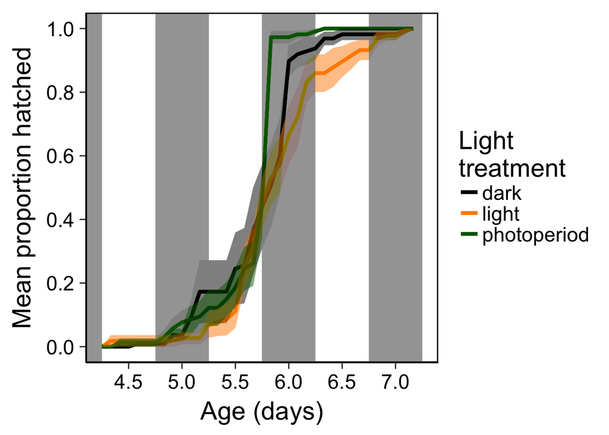

```r
library(ggplot2)
library(scales)

legend_title="Light \ntreatment"

g1=ggplot(k, aes(x=age, y=mean)) + #add the axis
  geom_line(aes(color=treatment), size=1.5) + #make lines different colors... these are lines drawn b/t  the means, then make lines thicker... size="must be outside of aes"
  geom_ribbon(aes(ymin=mean-SE, ymax=mean+SE, group=treatment, fill=treatment), alpha=.5) + # make SE ribbon limits, then make 3 ribbon groups by treatment, the nfill them by color by treatment, alpha is see through-ness
  labs(y="Mean proportion hatched", x="Age (days)") + #creat labels...
  theme_classic(base_size=21) +
  theme(panel.background = element_rect(colour = "black", size=1), legend.position="right", axis.text.x = element_text(color="black"), axis.text.y = element_text(color="black")) +
  scale_x_continuous(breaks= pretty_breaks(n=6)) + # allows for making "pretty" breaks on x axis... only showing 4 and 5 values...
  scale_y_continuous(breaks= pretty_breaks(n=6)) + # allows for making "pretty" breaks on y axis... shows 5 breaks
  scale_color_manual(legend_title, values = c("black", "darkorange", "darkgreen")) +
  scale_fill_manual(guide = FALSE, values = c("black", "darkorange", "darkgreen")) + # remove title for shading colors...
  geom_rect(aes(xmin = -Inf, xmax = 4.25,
            ymin = -Inf, ymax = Inf), alpha = 0.009) +
  geom_rect(aes(xmin = 4.75, xmax = 5.25,
            ymin = -Inf, ymax = Inf), alpha = 0.009) +
  geom_rect(aes(xmin = 5.75, xmax = 6.25,
            ymin = -Inf, ymax = Inf), alpha = 0.009) +
  geom_rect(aes(xmin = 6.75, xmax = 7.25,
            ymin = -Inf, ymax = Inf), alpha = 0.009)
g1
```

### 3 panel figure

```r
library(ggplot2)
library(scales)
library(dplyr)

levels(photopattern$treatment)
```

```
## [1] ""            "dark"        "light"       "photoperiod"
```

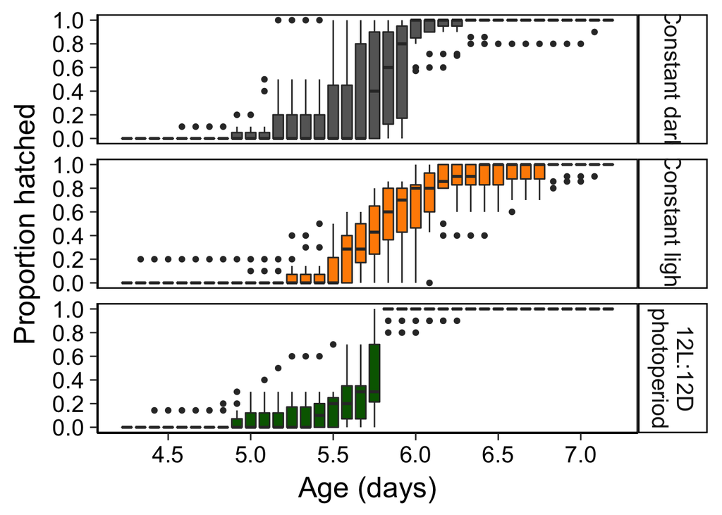

```r
levels(photopattern$treatment) <- c("", "Constant dark", "Constant light", "12L:12D\nphotoperiod")
g=ggplot(photopattern, aes(x=age, y=percentage)) + #add the axis
  geom_boxplot(aes(group=age, fill=treatment)) + #make lines different colors... these are lines drawn b/t  the means, then make lines thicker... size="must be outside of aes"
  labs(y="Proportion hatched", x="Age (days)") + #creat labels...
  theme_classic(base_size=20) +
  theme(panel.background = element_rect(colour = "black", size=1), legend.position="right", axis.text.x = element_text(color="black"), axis.text.y = element_text(color="black")) +
  scale_x_continuous(breaks= pretty_breaks(n=6)) + # allows for making "pretty" breaks on x axis... only showing 4 and 5 values...
  scale_y_continuous(breaks= pretty_breaks(n=6)) + # allows for making "pretty" breaks on y axis... shows 5 breaks
  scale_color_manual(legend_title, values = c("gray40", "darkorange", "darkgreen")) +
  scale_fill_manual(guide = FALSE, values = c("gray40", "darkorange", "darkgreen")) +
  facet_grid(treatment~.) # remove title for shading colors...
g
```

## **General Hatching Process**

*ONSET*

```r
library(dplyr)
onset = photopattern %>%
  group_by(clutch, treatment) %>%
  filter(percentage != 0) %>% # get first hatching
  filter(percentage == min(percentage) & age == min(age)) %>% #get only first hatching per clutch and teratment
  dplyr::select(clutch, treatment, age, time, percentage) %>%
  arrange(clutch, treatment)
onset
```

```
## # A tibble: 33 x 5
## # Groups:   clutch, treatment [33]
##    clutch              treatment      age  time percentage
##     <int>                 <fctr>    <dbl> <int>      <dbl>
##  1    221          Constant dark 5.500000    30  0.3000000
##  2    221         Constant light 5.583333    32  0.3000000
##  3    221 "12L:12D\nphotoperiod" 4.916667    16  0.3000000
##  4    222          Constant dark 5.833333    38  0.1428571
##  5    222         Constant light 5.250000    24  0.1428571
##  6    222 "12L:12D\nphotoperiod" 5.750000    36  0.2857143
##  7    230          Constant dark 5.916667    40  0.2000000
##  8    230         Constant light 5.666667    34  0.2000000
##  9    230 "12L:12D\nphotoperiod" 5.416667    28  0.1000000
## 10    231          Constant dark 6.000000    42  0.6000000
## # ... with 23 more rows
```

```r
onset_summary = onset %>%
  group_by(treatment) %>%
  summarise(mean_onset_age = mean(age), SE= sd(age)/sqrt(length(age)), sample_size=n())
onset_summary
```

```
## # A tibble: 3 x 4
##                treatment mean_onset_age        SE sample_size
##                   <fctr>          <dbl>     <dbl>       <int>
## 1          Constant dark       5.515152 0.1451306          11
## 2         Constant light       5.462121 0.1427382          11
## 3 "12L:12D\nphotoperiod"       5.287879 0.1359421          11
```

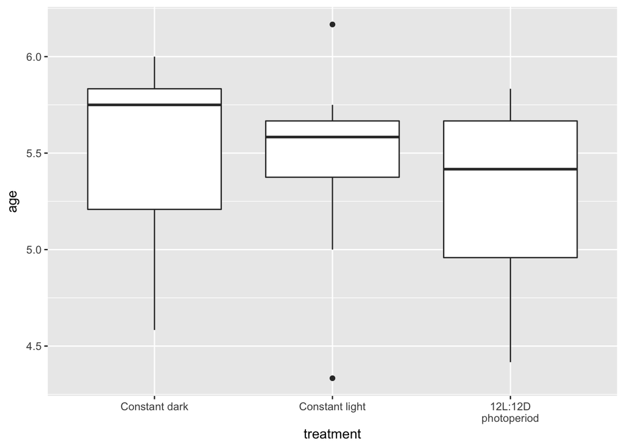

```r
ggplot(data=onset, aes(x=treatment, y=age)) +geom_boxplot()
```

> The onset of hatching for embryos in the dark, light, and photoperiod treatments was 5.52, 5.46, and 5.29 days respectively.

Stats:

```r
m=lm(data=onset, age~treatment)
summary(m)
```

```
##
## Call:
## lm(formula = age ~ treatment, data = onset)
##
## Residuals:
##     Min      1Q  Median      3Q     Max
## -1.1288 -0.2879  0.1288  0.2954  0.7046
##
## Coefficients:
##                               Estimate Std. Error t value Pr(>|t|)
## (Intercept)                    5.51515    0.14132  39.025   <2e-16 ***
## treatmentConstant light       -0.05303    0.19986  -0.265    0.793
## treatment12L:12D\nphotoperiod -0.22727    0.19986  -1.137    0.264
## ---
## Signif. codes:  0 '***' 0.001 '**' 0.01 '*' 0.05 '.' 0.1 ' ' 1
##
## Residual standard error: 0.4687 on 30 degrees of freedom
## Multiple R-squared:  0.04506,    Adjusted R-squared:  -0.0186
## F-statistic: 0.7079 on 2 and 30 DF,  p-value: 0.5007
```

```r
library(car)
Anova(m)
```

```
## Anova Table (Type II tests)
##
## Response: age
##           Sum Sq Df F value Pr(>F)
## treatment 0.3110  2  0.7079 0.5007
## Residuals 6.5909 30
```

```r
aov(m)
```

```
## Call:
##    aov(formula = m)
##
## Terms:
##                 treatment Residuals
## Sum of Squares   0.311027  6.590909
## Deg. of Freedom         2        30
##
## Residual standard error: 0.4687184
## Estimated effects may be unbalanced
```

```r
summary(aov(m))
```

```
##             Df Sum Sq Mean Sq F value Pr(>F)
## treatment    2  0.311  0.1555   0.708  0.501
## Residuals   30  6.591  0.2197
```

```r
#post hoc
TukeyHSD(aov(m))
```

```
##   Tukey multiple comparisons of means
##     95% family-wise confidence level
##
## Fit: aov(formula = m)
##
## $treatment
##                                           diff        lwr       upr
## Constant light-Constant dark        -0.0530303 -0.5457449 0.4396843
## 12L:12D\nphotoperiod-Constant dark  -0.2272727 -0.7199873 0.2654418
## 12L:12D\nphotoperiod-Constant light -0.1742424 -0.6669570 0.3184721
##                                         p adj
## Constant light-Constant dark        0.9619829
## 12L:12D\nphotoperiod-Constant dark  0.4992539
## 12L:12D\nphotoperiod-Constant light 0.6619119
```

- F value == 0.708; df= 2,30
- overall treatment **p-value** == 0.501 **NS**
- light-dark **p-value** == 0.9619829 **NS**
- photo-dark **p-value** == 0.4992539 **NS**
- photo-light **p-value** == 0.6619119 **NS**

Check for normality

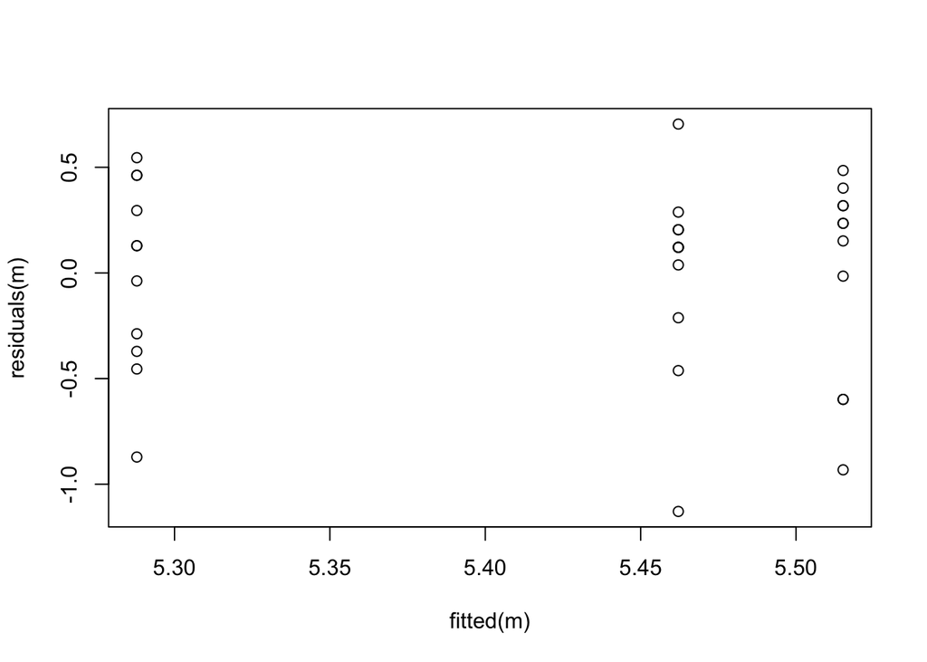

```r
plot(fitted(m), residuals(m))
```

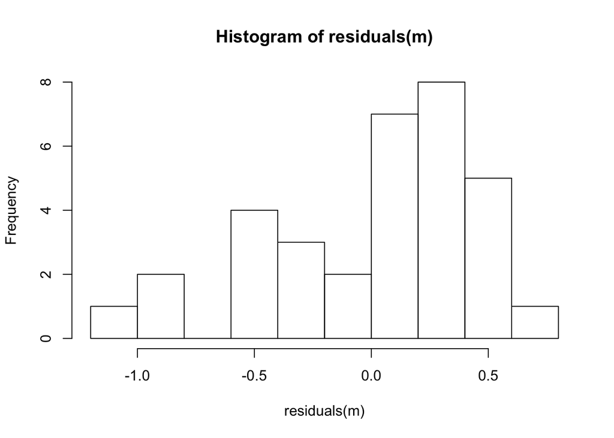

```r
hist(residuals(m))
```

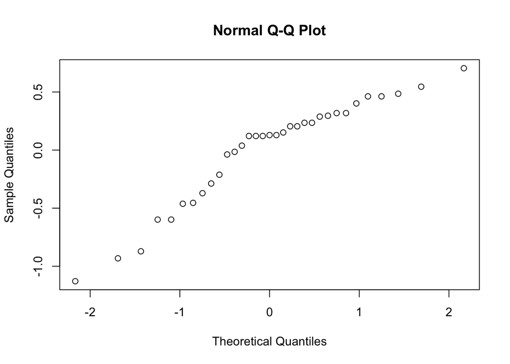

```r
qqnorm(residuals(m))
```

```r
shapiro.test(m$residuals)
```

```
##
##  Shapiro-Wilk normality test
##
## data:  m$residuals
## W = 0.91696, p-value = 0.01511
```

- shapiro test **p-value** == 0.01511

** NOT normally dist**

non-parametric tests

```r
library(FSA)
kwt=kruskal.test(data=onset, age~as.factor(treatment))
kwt
```

```
##
##  Kruskal-Wallis rank sum test
##
## data:  age by as.factor(treatment)
## Kruskal-Wallis chi-squared = 2.3325, df = 2, p-value = 0.3115
```

```r
dunnTest(data=onset, age~as.factor(treatment), method = "bh")
```

```
## Dunn (1964) Kruskal-Wallis multiple comparison
```

```
##   p-values adjusted with the Benjamini-Hochberg method.
```

```
##                              Comparison          Z   P.unadj     P.adj
## 1  12L:12D\nphotoperiod - Constant dark -1.5272412 0.1267010 0.3801031
## 2 12L:12D\nphotoperiod - Constant light -0.7636206 0.4450934 0.4450934
## 3        Constant dark - Constant light  0.7636206 0.4450934 0.6676400
```

> interpretation: onset of hatching is not different between treatments

*FIFTY PERCENT*

```r
library(dplyr)
fiftypercent = photopattern %>%
  group_by(clutch, treatment) %>%
  filter(percentage >= .50) %>% # get first hatching
  dplyr::select(clutch, treatment, age, time, percentage) %>%
  arrange(clutch, treatment) %>%
  filter(percentage == min(percentage) & age == min(age)) #get only first hatching per clutch and teratment
fiftypercent
```

```
## # A tibble: 33 x 5
## # Groups:   clutch, treatment [33]
##    clutch              treatment      age  time percentage
##     <int>                 <fctr>    <dbl> <int>      <dbl>
##  1    221          Constant dark 5.750000    36        0.5
##  2    221         Constant light 5.750000    36        0.5
##  3    221 "12L:12D\nphotoperiod" 5.833333    38        0.9
##  4    222          Constant dark 6.000000    42        1.0
##  5    222         Constant light 6.166667    46        1.0
##  6    222 "12L:12D\nphotoperiod" 5.833333    38        1.0
##  7    230          Constant dark 6.000000    42        0.9
##  8    230         Constant light 6.000000    42        0.7
##  9    230 "12L:12D\nphotoperiod" 5.750000    36        0.8
## 10    231          Constant dark 6.000000    42        0.6
## # ... with 23 more rows
```

```r
fiftypercent_summary = fiftypercent %>%
  group_by(treatment) %>%
  summarise(mean_fiftypercent_age = mean(age), SE= sd(age)/sqrt(length(age)), sample_size=n())
fiftypercent_summary
```

```
## # A tibble: 3 x 4
##                treatment mean_fiftypercent_age         SE sample_size
##                   <fctr>                 <dbl>      <dbl>       <int>
## 1          Constant dark              5.719697 0.10130009          11
## 2         Constant light              5.871212 0.09290733          11
## 3 "12L:12D\nphotoperiod"              5.734848 0.06135896          11
```

> Embryos in the dark, light, and photoperiod treatments reached 50% hatching completion at 5.72, 5.87, and 5.73 days respectively.

Stats:

```r
m=lm(data=fiftypercent, age~treatment)
summary(m)
```

```
##
## Call:
## lm(formula = age ~ treatment, data = fiftypercent)
##
## Residuals:
##      Min       1Q   Median       3Q      Max
## -0.63636 -0.12121  0.09848  0.12879  0.62879
##
## Coefficients:
##                               Estimate Std. Error t value Pr(>|t|)
## (Intercept)                    5.71970    0.08691  65.814   <2e-16 ***
## treatmentConstant light        0.15152    0.12290   1.233    0.227
## treatment12L:12D\nphotoperiod  0.01515    0.12290   0.123    0.903
## ---
## Signif. codes:  0 '***' 0.001 '**' 0.01 '*' 0.05 '.' 0.1 ' ' 1
##
## Residual standard error: 0.2882 on 30 degrees of freedom
## Multiple R-squared:  0.05791,    Adjusted R-squared:  -0.0049
## F-statistic: 0.922 on 2 and 30 DF,  p-value: 0.4087
```

```r
library(car)
Anova(m)
```

```
## Anova Table (Type II tests)
##
## Response: age
##           Sum Sq Df F value Pr(>F)
## treatment 0.1532  2   0.922 0.4087
## Residuals 2.4924 30
```

```r
aov(m)
```

```
## Call:
##    aov(formula = m)
##
## Terms:
##                 treatment Residuals
## Sum of Squares  0.1531987 2.4924242
## Deg. of Freedom         2        30
##
## Residual standard error: 0.2882374
## Estimated effects may be unbalanced
```

```r
summary(aov(m))
```

```
##             Df Sum Sq Mean Sq F value Pr(>F)
## treatment    2 0.1532 0.07660   0.922  0.409
## Residuals   30 2.4924 0.08308
```

```r
#post hoc
TukeyHSD(aov(m))
```

```
##   Tukey multiple comparisons of means
##     95% family-wise confidence level
##
## Fit: aov(formula = m)
##
## $treatment
##                                            diff        lwr       upr
## Constant light-Constant dark         0.15151515 -0.1514786 0.4545089
## 12L:12D\nphotoperiod-Constant dark   0.01515151 -0.2878423 0.3181453
## 12L:12D\nphotoperiod-Constant light -0.13636364 -0.4393574 0.1666302
##                                         p adj
## Constant light-Constant dark        0.4436152
## 12L:12D\nphotoperiod-Constant dark  0.9916588
## 12L:12D\nphotoperiod-Constant light 0.5157742
```

- F value == 0.922; df= 2,30
- overall treatment **p-value** == 0.409 **NS**
- light-dark **p-value** == 0.4436152 **NS**
- photo-dark **p-value** == 0.9916588 **NS**
- photo-light **p-value** == 0.5157742 **NS**

Check for normality

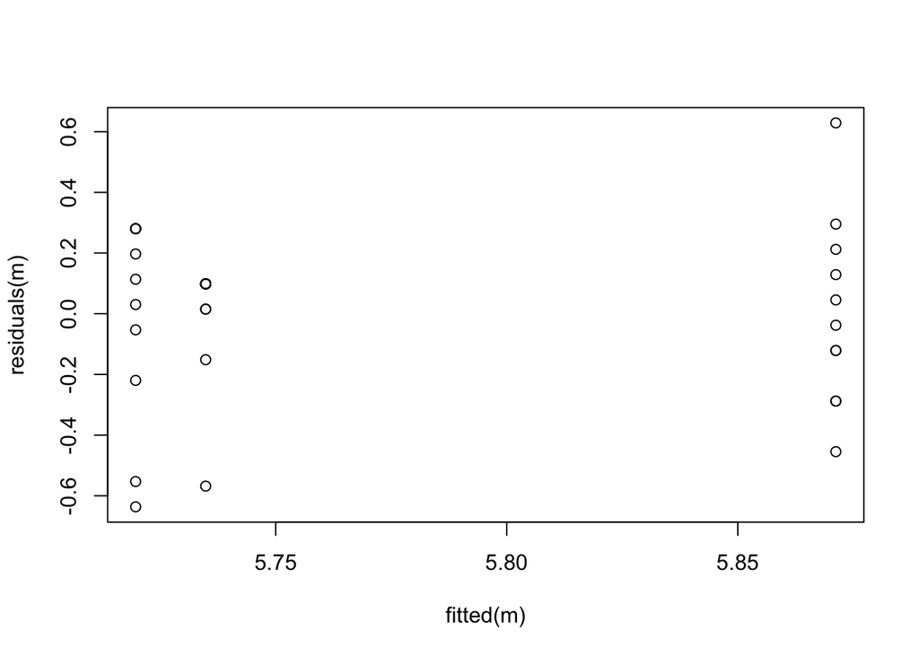

```r
plot(fitted(m), residuals(m))
```

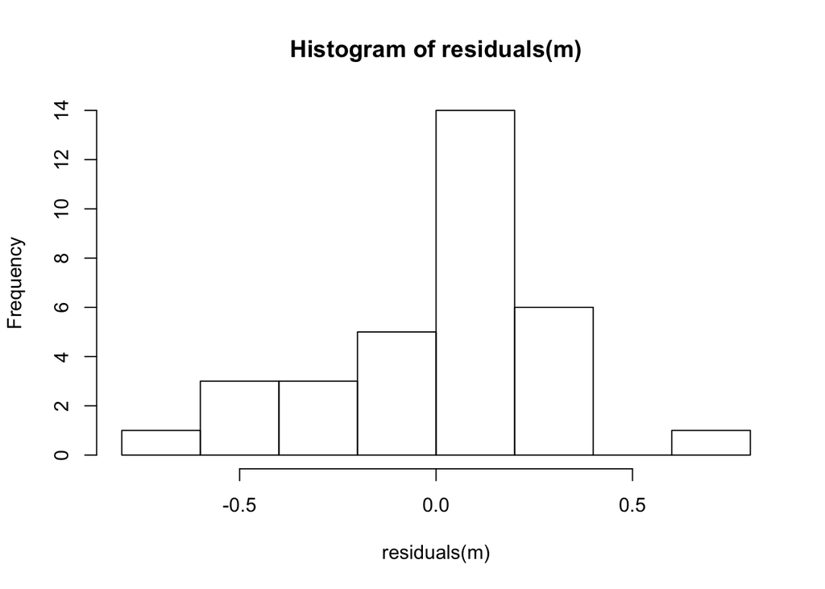

```r
hist(residuals(m))
```

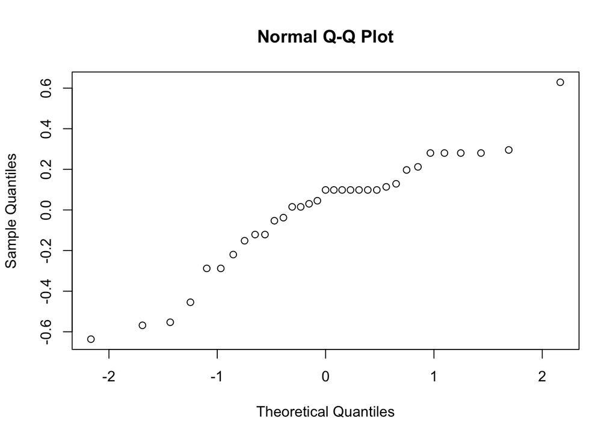

```r
qqnorm(residuals(m))
```

```r
shapiro.test(m$residuals)
```

```
##
##  Shapiro-Wilk normality test
##
## data:  m$residuals
## W = 0.93462, p-value = 0.04747
```

- shapiro test **p-value** == 0.04747

** NOT normally dist**

non-parametric tests

```r
library(FSA)
kwt=kruskal.test(data=fiftypercent, age~as.factor(treatment))
kwt
```

```
##
##  Kruskal-Wallis rank sum test
##
## data:  age by as.factor(treatment)
## Kruskal-Wallis chi-squared = 0.93053, df = 2, p-value = 0.628
```

```r
dunnTest(data=fiftypercent, age~as.factor(treatment), method = "bh")
```

```
## Dunn (1964) Kruskal-Wallis multiple comparison
```

```
##   p-values adjusted with the Benjamini-Hochberg method.
```

```
##                              Comparison          Z   P.unadj     P.adj
## 1  12L:12D\nphotoperiod - Constant dark -0.4136790 0.6791092 0.6791092
## 2 12L:12D\nphotoperiod - Constant light -0.9615243 0.3362886 1.0000000
## 3        Constant dark - Constant light -0.5478452 0.5837982 0.8756973
```

- X^2 == 0.93053
- overall treatment **p-value** == 0.628 **NS**
- light-dark **p-value** == 0.8756973 **NS**
- photo-dark **p-value** == 0.6791092 **NS**
- photo-light **p-value** == 1.0000000 **NS**

> interpretation: embryos all reach 50% at the same age

*COMPLETION*

```r
library(dplyr)
completion = photopattern %>%
  group_by(clutch, treatment) %>%
  filter(percentage == 1) %>% # get first hatching
  filter(percentage == min(percentage) & age == min(age)) %>% #get only first hatching per clutch and teratment
  dplyr::select(clutch, treatment, age, time, percentage) %>%
  arrange(clutch, treatment)
completion
```

```
## # A tibble: 33 x 5
## # Groups:   clutch, treatment [33]
##    clutch              treatment      age  time percentage
##     <int>                 <fctr>    <dbl> <int>      <dbl>
##  1    221          Constant dark 6.000000    42          1
##  2    221         Constant light 6.000000    42          1
##  3    221 "12L:12D\nphotoperiod" 6.333333    50          1
##  4    222          Constant dark 6.000000    42          1
##  5    222         Constant light 6.166667    46          1
##  6    222 "12L:12D\nphotoperiod" 5.833333    38          1
##  7    230          Constant dark 6.166667    46          1
##  8    230         Constant light 6.416667    52          1
##  9    230 "12L:12D\nphotoperiod" 5.833333    38          1
## 10    231          Constant dark 7.166667    70          1
## # ... with 23 more rows
```

```r
completion_summary = completion %>%
  group_by(treatment) %>%
  summarise(mean_completion_age = mean(age), SE= sd(age)/sqrt(length(age)), sample_size=n())
completion_summary
```

```
## # A tibble: 3 x 4
##                treatment mean_completion_age         SE sample_size
##                   <fctr>               <dbl>      <dbl>       <int>
## 1          Constant dark            6.060606 0.15451574          11
## 2         Constant light            6.469697 0.13165263          11
## 3 "12L:12D\nphotoperiod"            5.909091 0.05779464          11
```

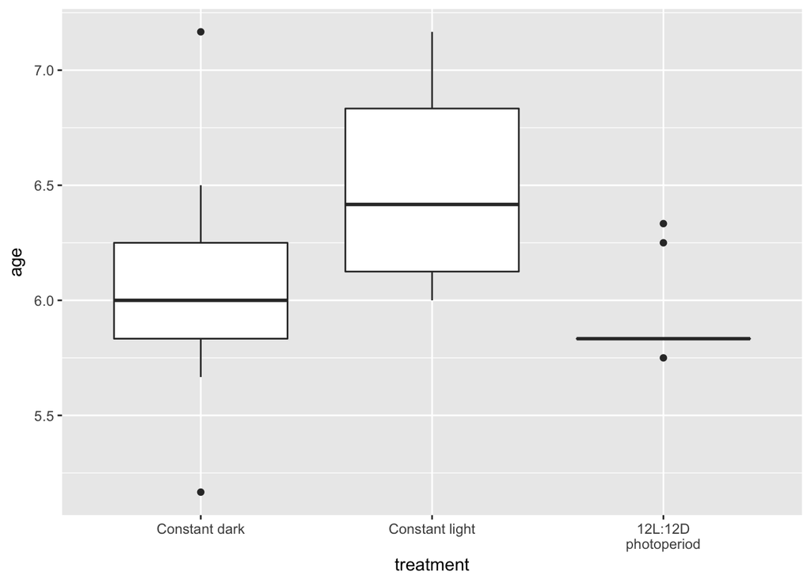

```r
ggplot(data=completion, aes(x=treatment, y=age)) +geom_boxplot()
```

> Embryos in the dark, light, and photoperiod treatments reached hatching completion at 6.06, 6.47, and 5.91 days respectively.

Stats:

```r
m=lm(data=completion, age~treatment)
summary(m)
```

```
##
## Call:
## lm(formula = age ~ treatment, data = completion)
##
## Residuals:
##      Min       1Q   Median       3Q      Max
## -0.89394 -0.15909 -0.07576  0.27273  1.10606
##
## Coefficients:
##                               Estimate Std. Error t value Pr(>|t|)
## (Intercept)                     6.0606     0.1219  49.735   <2e-16 ***
## treatmentConstant light         0.4091     0.1723   2.374   0.0242 *
## treatment12L:12D\nphotoperiod  -0.1515     0.1723  -0.879   0.3863
## ---
## Signif. codes:  0 '***' 0.001 '**' 0.01 '*' 0.05 '.' 0.1 ' ' 1
##
## Residual standard error: 0.4042 on 30 degrees of freedom
## Multiple R-squared:  0.2741, Adjusted R-squared:  0.2257
## F-statistic: 5.663 on 2 and 30 DF,  p-value: 0.008191
```

```r
library(car)
Anova(m)
```

```
## Anova Table (Type II tests)
##
## Response: age
##           Sum Sq Df F value   Pr(>F)
## treatment 1.8502  2  5.6635 0.008191 **
## Residuals 4.9003 30
## ---
## Signif. codes:  0 '***' 0.001 '**' 0.01 '*' 0.05 '.' 0.1 ' ' 1
```

```r
aov(m)
```

```
## Call:
##    aov(formula = m)
##
## Terms:
##                 treatment Residuals
## Sum of Squares   1.850168  4.900253
## Deg. of Freedom         2        30
##
## Residual standard error: 0.4041556
## Estimated effects may be unbalanced
```

```r
summary(aov(m))
```

```
##             Df Sum Sq Mean Sq F value  Pr(>F)
## treatment    2   1.85  0.9251   5.663 0.00819 **
## Residuals   30   4.90  0.1633
## ---
## Signif. codes:  0 '***' 0.001 '**' 0.01 '*' 0.05 '.' 0.1 ' ' 1
```

```r
#post hoc
TukeyHSD(aov(m))
```

```
##   Tukey multiple comparisons of means
##     95% family-wise confidence level
##
## Fit: aov(formula = m)
##
## $treatment
##                                           diff         lwr        upr
## Constant light-Constant dark         0.4090909 -0.01575552  0.8339373
## 12L:12D\nphotoperiod-Constant dark  -0.1515152 -0.57636158  0.2733313
## 12L:12D\nphotoperiod-Constant light -0.5606061 -0.98545249 -0.1357596
##                                         p adj
## Constant light-Constant dark        0.0609168
## 12L:12D\nphotoperiod-Constant dark  0.6573500
## 12L:12D\nphotoperiod-Constant light 0.0077221
```

- F value == 5.6635; df= 2,30
- overall treatment **p-value** == 0.008191 ***
- light-dark **p-value** == 0.0609168 **NS**
- photo-dark **p-value** == 0.6573500 **NS**
- photo-light **p-value** == 0.0077221 ***

Check for normality

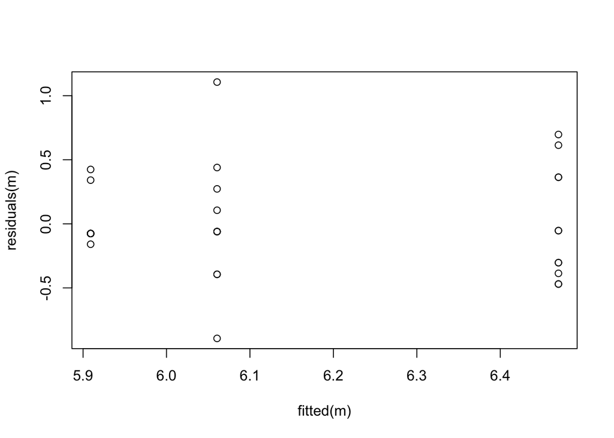

```r
plot(fitted(m), residuals(m))
```

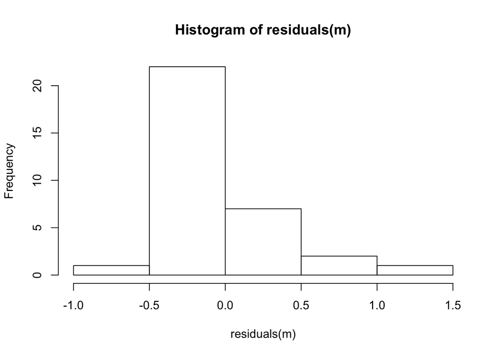

```r
hist(residuals(m))
```

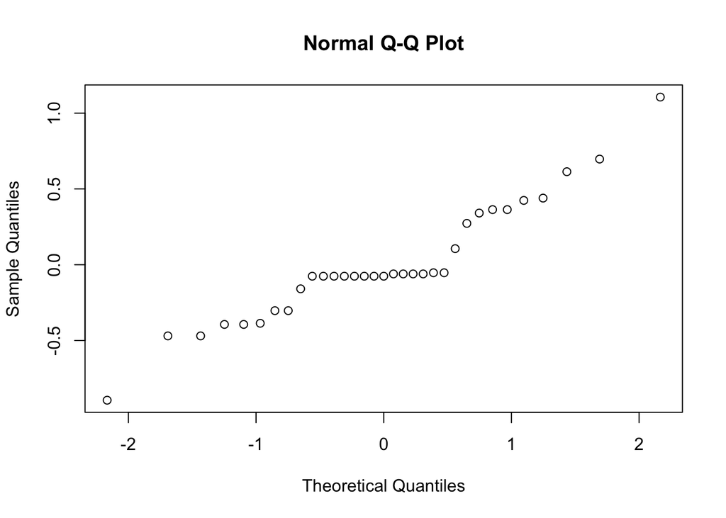

```r
qqnorm(residuals(m))
```

```r
shapiro.test(m$residuals)
```

```
##
##  Shapiro-Wilk normality test
##
## data:  m$residuals
## W = 0.93066, p-value = 0.03655
```

- shapiro test **p-value** == 0.03655

** NOT normally dist**

non-parametric tests

```r
library(FSA)
kwt=kruskal.test(data=completion, age~as.factor(treatment))
kwt
```

```
##
##  Kruskal-Wallis rank sum test
##
## data:  age by as.factor(treatment)
## Kruskal-Wallis chi-squared = 11.133, df = 2, p-value = 0.003824
```

```r
dunnTest(data=completion, age~as.factor(treatment), method = "bh")
```

```
## Dunn (1964) Kruskal-Wallis multiple comparison
```

```
##   p-values adjusted with the Benjamini-Hochberg method.
```

```
##                              Comparison         Z      P.unadj       P.adj
## 1  12L:12D\nphotoperiod - Constant dark -1.214716 0.2244745743 0.224474574
## 2 12L:12D\nphotoperiod - Constant light -3.298677 0.0009714152 0.002914246
## 3        Constant dark - Constant light -2.083962 0.0371636554 0.055745483
```

> interpretation: embryos in photoperiod reach hatching completion before those in light treatment but not differently than those in dark.

## **PEAK HATCHING**

Take data from time points 34 and 38 before and after 36 when lights when off to see peak H after onset of darkness…

```r
library(dplyr)
peak = photopattern %>%
  filter(time == 34 | time == 38)
peak
```

```
##        date clutch            treatment age_days      age time.of.day time
## 1  20150805    221        Constant dark        5 5.666667          16   34
## 2  20150805    222        Constant dark        5 5.666667          16   34
## 3  20150805    230        Constant dark        5 5.666667          16   34
## 4  20150805    231        Constant dark        5 5.666667          16   34
## 5  20150805    232        Constant dark        5 5.666667          16   34
## 6  20150805    233        Constant dark        5 5.666667          16   34
## 7  20150805    234        Constant dark        5 5.666667          16   34
## 8  20150805    235        Constant dark        5 5.666667          16   34
## 9  20150805    236        Constant dark        5 5.666667          16   34
## 10 20150805    239        Constant dark        5 5.666667          16   34
## 11 20150805    240        Constant dark        5 5.666667          16   34
## 12 20150805    221       Constant light        5 5.666667          16   34
## 13 20150805    222       Constant light        5 5.666667          16   34
## 14 20150805    230       Constant light        5 5.666667          16   34
```

[output cut: 119 more lines]

```r
minmax_peak= peak %>%
  group_by(clutch, treatment) %>%
  summarise(min=min(percentage), max=max(percentage)) %>%
  mutate(diff = max - min)
minmax_peak
```

```
## # A tibble: 33 x 5
## # Groups:   clutch [11]
##    clutch              treatment       min       max      diff
##     <int>                 <fctr>     <dbl>     <dbl>     <dbl>
##  1    221          Constant dark 0.4000000 0.6000000 0.2000000
##  2    221         Constant light 0.3000000 0.6000000 0.3000000
##  3    221 "12L:12D\nphotoperiod" 0.4000000 0.9000000 0.5000000
##  4    222          Constant dark 0.0000000 0.1428571 0.1428571
##  5    222         Constant light 0.2857143 0.4285714 0.1428571
##  6    222 "12L:12D\nphotoperiod" 0.0000000 1.0000000 1.0000000
##  7    230          Constant dark 0.0000000 0.0000000 0.0000000
##  8    230         Constant light 0.2000000 0.2000000 0.0000000
##  9    230 "12L:12D\nphotoperiod" 0.3000000 1.0000000 0.7000000
## 10    231          Constant dark 0.0000000 0.0000000 0.0000000
## # ... with 23 more rows
```

### Stats:

```r
m=lm(data=minmax_peak, diff~treatment)
summary(m)
```

```
##
## Call:
## lm(formula = diff ~ treatment, data = minmax_peak)
##
## Residuals:
##      Min       1Q   Median       3Q      Max
## -0.41039 -0.14416 -0.01039  0.08182  0.65584
##
## Coefficients:
##                               Estimate Std. Error t value Pr(>|t|)
## (Intercept)                    0.14416    0.06782   2.126   0.0419 *
## treatmentConstant light        0.07403    0.09591   0.772   0.4463
## treatment12L:12D\nphotoperiod  0.56623    0.09591   5.904 1.83e-06 ***
## ---
## Signif. codes:  0 '***' 0.001 '**' 0.01 '*' 0.05 '.' 0.1 ' ' 1
##
## Residual standard error: 0.2249 on 30 degrees of freedom
## Multiple R-squared:  0.5786, Adjusted R-squared:  0.5505
## F-statistic:  20.6 on 2 and 30 DF,  p-value: 2.346e-06
```

```r
library(car)
Anova(m)
```

```
## Anova Table (Type II tests)
##
## Response: diff
##           Sum Sq Df F value    Pr(>F)
## treatment 2.0840  2  20.596 2.346e-06 ***
## Residuals 1.5178 30
## ---
## Signif. codes:  0 '***' 0.001 '**' 0.01 '*' 0.05 '.' 0.1 ' ' 1
```

```r
aov(m)
```

```
## Call:
##    aov(formula = m)
##
## Terms:
##                 treatment Residuals
## Sum of Squares   2.084020  1.517811
## Deg. of Freedom         2        30
##
## Residual standard error: 0.2249304
## Estimated effects may be unbalanced
```

```r
summary(aov(m))
```

```
##             Df Sum Sq Mean Sq F value   Pr(>F)
## treatment    2  2.084  1.0420    20.6 2.35e-06 ***
## Residuals   30  1.518  0.0506
## ---
## Signif. codes:  0 '***' 0.001 '**' 0.01 '*' 0.05 '.' 0.1 ' ' 1
```

```r
#post hoc
TukeyHSD(aov(m))
```

```
##   Tukey multiple comparisons of means
##     95% family-wise confidence level
##
## Fit: aov(formula = m)
##
## $treatment
##                                           diff        lwr       upr
## Constant light-Constant dark        0.07402597 -0.1624198 0.3104717
## 12L:12D\nphotoperiod-Constant dark  0.56623377  0.3297880 0.8026795
## 12L:12D\nphotoperiod-Constant light 0.49220779  0.2557620 0.7286536
##                                         p adj
## Constant light-Constant dark        0.7229111
## 12L:12D\nphotoperiod-Constant dark  0.0000054
## 12L:12D\nphotoperiod-Constant light 0.0000467
```

> interpretation: Here we see that treatment has an effect on the diff b/t proportion hatched before and after darkness; specifically, the photo treatment was effected very strongly in proportion hatched compared to other treatments by the onset of darkness

Check for normality

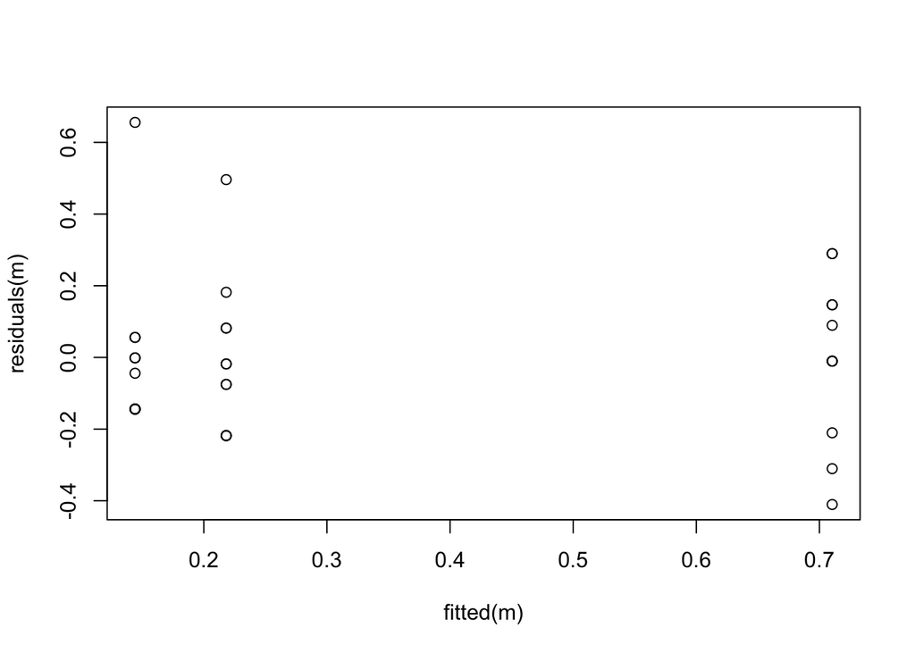

```r
plot(fitted(m), residuals(m))
```

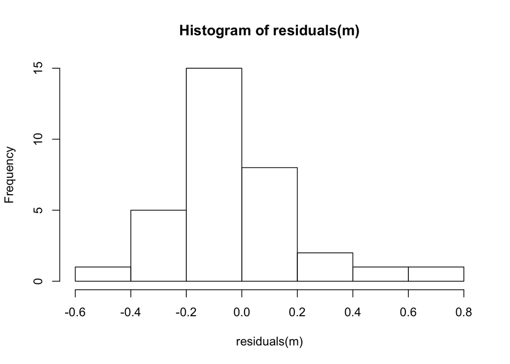

```r
hist(residuals(m))
```

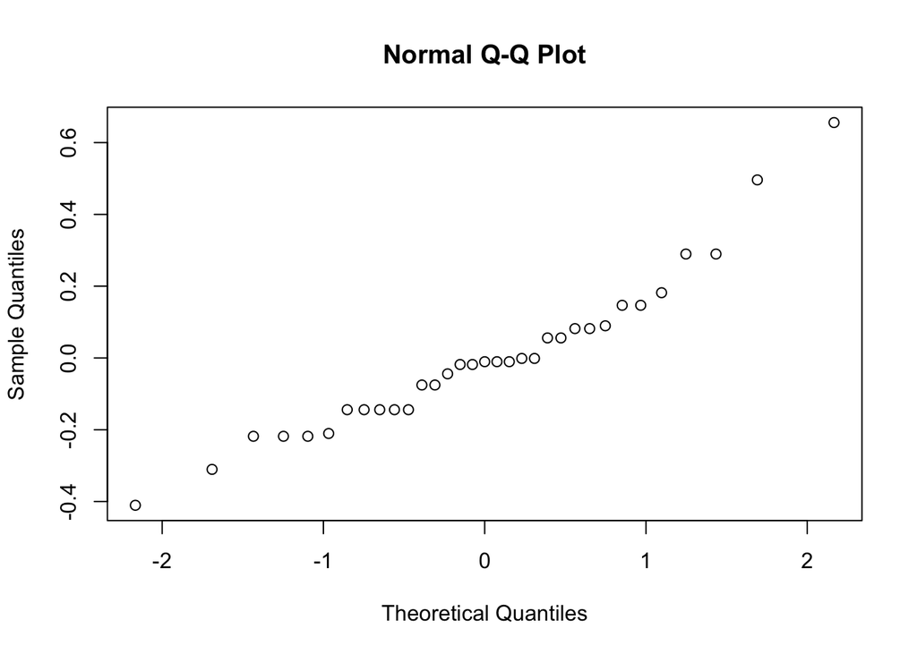

```r
qqnorm(residuals(m))
```

```r
shapiro.test(m$residuals)
```

```
##
##  Shapiro-Wilk normality test
##
## data:  m$residuals
## W = 0.93601, p-value = 0.05205
```

- shapiro test **p-value** == 0.05205

***NORMALLy DIST** so stats are good!

### Visualization

```r
mpeak = minmax_peak %>%
  group_by(treatment) %>%
  summarise(mean_diff= mean(diff), SE= sd(diff)/sqrt(length(diff)), sample_size=n())
mpeak
```

```
## # A tibble: 3 x 4
##                treatment mean_diff         SE sample_size
##                   <fctr>     <dbl>      <dbl>       <int>
## 1          Constant dark 0.1441558 0.07020919          11
## 2         Constant light 0.2181818 0.06377404          11
## 3 "12L:12D\nphotoperiod" 0.7103896 0.06929518          11
```

```r
levels(photopattern$treatment)
```

```
## [1] ""                     "Constant dark"        "Constant light"
## [4] "12L:12D\nphotoperiod"
```

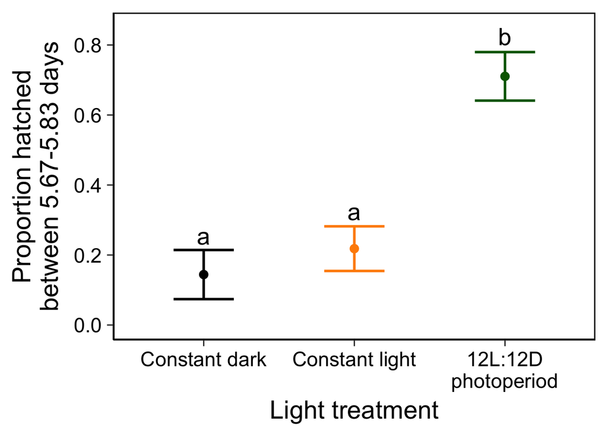

```r
levels(photopattern$treatment) <- c("", "dark", "light", "photoperiod")

library(ggplot2)
legend_title="Light \ntreatment" #make legend title here

g = ggplot(data=mpeak, aes(x= treatment, y= mean_diff)) +
  geom_point(aes(color= treatment), size= 3) +
  geom_errorbar(aes(ymin=mean_diff-SE, ymax=mean_diff+SE, color = treatment), width= .4, size= 1) +
  labs(y="Proportion hatched\nbetween 5.67-5.83 days", x="Light treatment") +
  scale_y_continuous(limits=c(0,0.85), oob = rescale_none, breaks= pretty_breaks(n=4)) +
  scale_color_manual(legend_title,values = c("black", "darkorange", "darkgreen")) +
  geom_text(aes(y = c(0.23, 0.3, 0.8), label = c("a", "a", "b")), position = position_dodge(width = .8), color= "black", vjust = 0, size = 7) +
  theme_classic(base_size = 21) +
  theme(panel.background = element_rect(colour = "black", size=1), legend.position="none", axis.text.x = element_text(color="black"), axis.text.y = element_text(color="black"))

g
```

## **SYNCHRONY WITHIN clutches** Analysis

> here lets find the max proportion hatched (max difference between any two time points) between any 2 time points…

```r
synchrony = photopattern %>%
  group_by(treatment) %>%
  filter(time == 36 | time == 38)
synchrony
```

```
## # A tibble: 66 x 14
## # Groups:   treatment [3]
##        date clutch treatment age_days   age time.of.day  time time_group
##       <int>  <int>    <fctr>    <int> <dbl>       <int> <int>      <int>
##  1 20150805    221      dark        5  5.75          18    36          7
##  2 20150805    222      dark        5  5.75          18    36          7
##  3 20150805    230      dark        5  5.75          18    36          7
##  4 20150805    231      dark        5  5.75          18    36          7
##  5 20150805    232      dark        5  5.75          18    36          7
##  6 20150805    233      dark        5  5.75          18    36          7
##  7 20150805    234      dark        5  5.75          18    36          7
##  8 20150805    235      dark        5  5.75          18    36          7
##  9 20150805    236      dark        5  5.75          18    36          7
## 10 20150805    239      dark        5  5.75          18    36          7
## # ... with 56 more rows, and 6 more variables: intial...eggs <int>,
## #   total_hatched <int>, H <int>, NH <int>, percentage <dbl>, notes <fctr>
```

```r
synch_diff= synchrony %>%
  group_by(treatment, clutch) %>%
  summarise(mean= mean(percentage), min=min(percentage), max=max(percentage)) %>%
  mutate(diff = max - min)
synch_diff
```

```
## # A tibble: 33 x 6
## # Groups:   treatment [3]
##    treatment clutch       mean       min       max      diff
##       <fctr>  <int>      <dbl>     <dbl>     <dbl>     <dbl>
##  1      dark    221 0.55000000 0.5000000 0.6000000 0.1000000
##  2      dark    222 0.07142857 0.0000000 0.1428571 0.1428571
##  3      dark    230 0.00000000 0.0000000 0.0000000 0.0000000
##  4      dark    231 0.00000000 0.0000000 0.0000000 0.0000000
##  5      dark    232 1.00000000 1.0000000 1.0000000 0.0000000
##  6      dark    233 1.00000000 1.0000000 1.0000000 0.0000000
##  7      dark    234 0.05000000 0.0000000 0.1000000 0.1000000
##  8      dark    235 0.60000000 0.4000000 0.8000000 0.4000000
##  9      dark    236 0.80000000 0.8000000 0.8000000 0.0000000
## 10      dark    239 0.14285714 0.1428571 0.1428571 0.0000000
## # ... with 23 more rows
```

```r
synch_sum = synch_diff %>%
  group_by(treatment) %>%
  summarise(mean_diff= mean(diff), SE= sd(diff)/sqrt(length(diff)), sample_size=n())
synch_sum
```

```
## # A tibble: 3 x 4
##     treatment  mean_diff         SE sample_size
##        <fctr>      <dbl>      <dbl>       <int>
## 1        dark 0.06753247 0.03695712          11
## 2       light 0.07922078 0.03873528          11
## 3 photoperiod 0.52987013 0.09396353          11
```

- dark: 40–>42 ———- 0.29870130
- light: 30–>32 ———- 0.140259740
- photo: 36–>38 ———- 0.52987013

> now lets just get that data

```r
synch = photopattern %>%
  group_by(treatment) %>%
  filter(time == 40 & treatment == "dark" | time == 42 & treatment == "dark" | time == 30 & treatment == "light" | time == 32 & treatment == "light" | time == 36 & treatment == "photoperiod" | time == 38 & treatment == "photoperiod")
synch
```

```
## # A tibble: 66 x 14
## # Groups:   treatment [3]
##        date clutch treatment age_days   age time.of.day  time time_group
##       <int>  <int>    <fctr>    <int> <dbl>       <int> <int>      <int>
##  1 20150805    221     light        5   5.5          12    30          6
##  2 20150805    222     light        5   5.5          12    30          6
##  3 20150805    230     light        5   5.5          12    30          6
##  4 20150805    231     light        5   5.5          12    30          6
##  5 20150805    232     light        5   5.5          12    30          6
##  6 20150805    233     light        5   5.5          12    30          6
##  7 20150805    234     light        5   5.5          12    30          6
##  8 20150805    235     light        5   5.5          12    30          6
##  9 20150805    236     light        5   5.5          12    30          6
## 10 20150805    239     light        5   5.5          12    30          6
## # ... with 56 more rows, and 6 more variables: intial...eggs <int>,
## #   total_hatched <int>, H <int>, NH <int>, percentage <dbl>, notes <fctr>
```

```r
synch_diff= synch %>%
  group_by(treatment, clutch) %>%
  summarise(mean= mean(percentage), min=min(percentage), max=max(percentage)) %>%
  mutate(diff = max - min)
synch_diff
```

```
## # A tibble: 33 x 6
## # Groups:   treatment [3]
##    treatment clutch      mean       min       max      diff
##       <fctr>  <int>     <dbl>     <dbl>     <dbl>     <dbl>
##  1      dark    221 0.8000000 0.6000000 1.0000000 0.4000000
##  2      dark    222 0.5714286 0.1428571 1.0000000 0.8571429
##  3      dark    230 0.5500000 0.2000000 0.9000000 0.7000000
##  4      dark    231 0.3000000 0.0000000 0.6000000 0.6000000
##  5      dark    232 1.0000000 1.0000000 1.0000000 0.0000000
##  6      dark    233 1.0000000 1.0000000 1.0000000 0.0000000
##  7      dark    234 0.8000000 0.8000000 0.8000000 0.0000000
##  8      dark    235 0.9000000 0.8000000 1.0000000 0.2000000
##  9      dark    236 0.9500000 0.9000000 1.0000000 0.1000000
## 10      dark    239 0.3571429 0.1428571 0.5714286 0.4285714
## # ... with 23 more rows
```

```r
synch_sum = synch_diff %>%
  group_by(treatment) %>%
  summarise(mean_diff= mean(diff), SE= sd(diff)/sqrt(length(diff)), sample_size=n())
synch_sum
```

```
## # A tibble: 3 x 4
##     treatment mean_diff         SE sample_size
##        <fctr>     <dbl>      <dbl>       <int>
## 1        dark 0.2987013 0.09519932          11
## 2       light 0.1402597 0.05081226          11
## 3 photoperiod 0.5298701 0.09396353          11
```

### Stats:

```r
m=lm(data=synch_diff, diff~treatment)
summary(m)
```

```
##
## Call:
## lm(formula = diff ~ treatment, data = synch_diff)
##
## Residuals:
##      Min       1Q   Median       3Q      Max
## -0.52987 -0.14026 -0.02987  0.17013  0.55844
##
## Coefficients:
##                      Estimate Std. Error t value Pr(>|t|)
## (Intercept)           0.29870    0.08261   3.616  0.00108 **
## treatmentlight       -0.15844    0.11683  -1.356  0.18517
## treatmentphotoperiod  0.23117    0.11683   1.979  0.05710 .
## ---
## Signif. codes:  0 '***' 0.001 '**' 0.01 '*' 0.05 '.' 0.1 ' ' 1
##
## Residual standard error: 0.274 on 30 degrees of freedom
## Multiple R-squared:  0.2727, Adjusted R-squared:  0.2242
## F-statistic: 5.625 on 2 and 30 DF,  p-value: 0.008422
```

```r
library(car)
Anova(m)
```

```
## Anova Table (Type II tests)
##
## Response: diff
##            Sum Sq Df F value   Pr(>F)
## treatment 0.84458  2  5.6252 0.008422 **
## Residuals 2.25213 30
## ---
## Signif. codes:  0 '***' 0.001 '**' 0.01 '*' 0.05 '.' 0.1 ' ' 1
```

```r
aov(m)
```

```
## Call:
##    aov(formula = m)
##
## Terms:
##                 treatment Residuals
## Sum of Squares  0.8445764 2.2521336
## Deg. of Freedom         2        30
##
## Residual standard error: 0.2739911
## Estimated effects may be unbalanced
```

```r
summary(aov(m))
```

```
##             Df Sum Sq Mean Sq F value  Pr(>F)
## treatment    2 0.8446  0.4223   5.625 0.00842 **
## Residuals   30 2.2521  0.0751
## ---
## Signif. codes:  0 '***' 0.001 '**' 0.01 '*' 0.05 '.' 0.1 ' ' 1
```

```r
#post hoc
TukeyHSD(aov(m))
```

```
##   Tukey multiple comparisons of means
##     95% family-wise confidence level
##
## Fit: aov(formula = m)
##
## $treatment
##                         diff         lwr       upr     p adj
## light-dark        -0.1584416 -0.44645968 0.1295766 0.3762132
## photoperiod-dark   0.2311688 -0.05684929 0.5191870 0.1349544
## photoperiod-light  0.3896104  0.10159227 0.6776285 0.0062725
```

> interpretation: Here we see that treatment has an effect on the max proportion hatched in any given 2 hour time period. The photo treatment was more synchronous than the light treatment, but not than the dark treatment

Check for normality

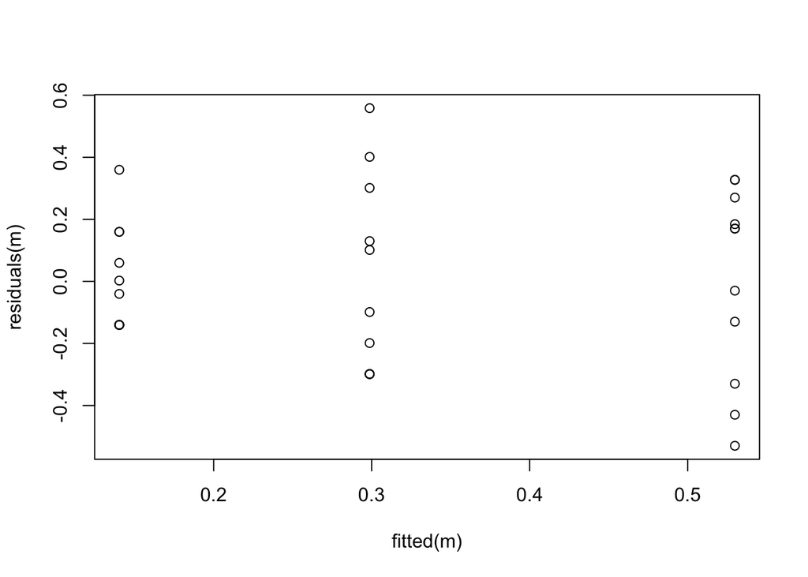

```r
plot(fitted(m), residuals(m))
```

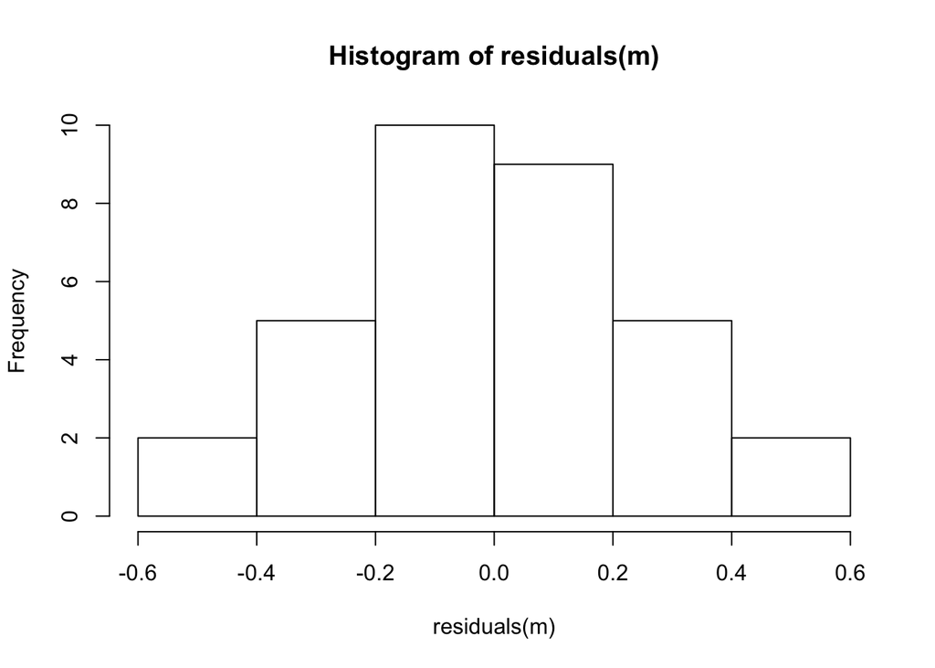

```r
hist(residuals(m))
```

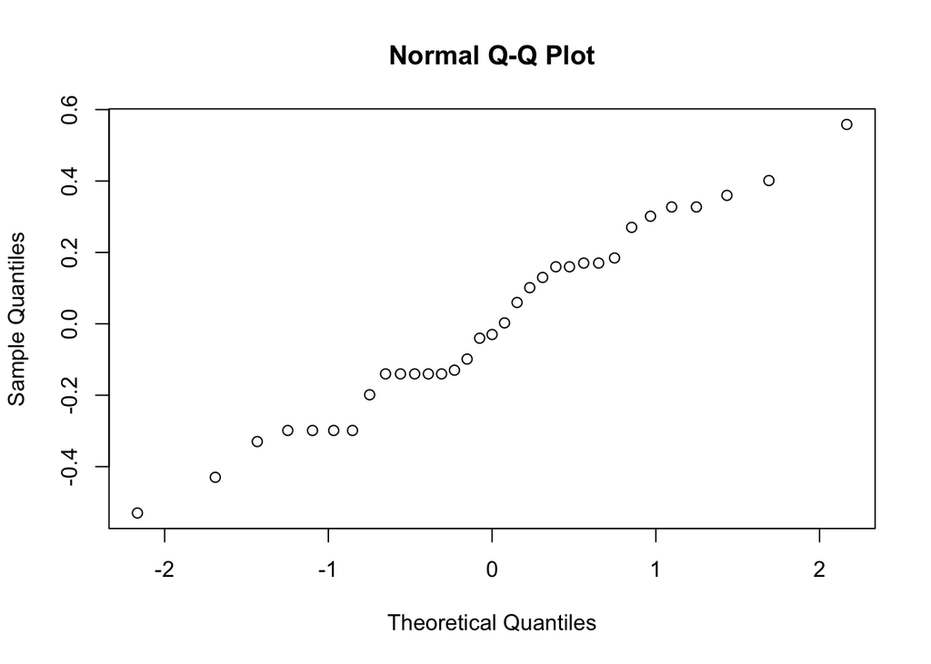

```r
qqnorm(residuals(m))
```

```r
shapiro.test(m$residuals)
```

```
##
##  Shapiro-Wilk normality test
##
## data:  m$residuals
## W = 0.97654, p-value = 0.6777
```

- shapiro test **p-value** == 0.6777

***NORMALLy DIST** so stats are good!

### Visualization

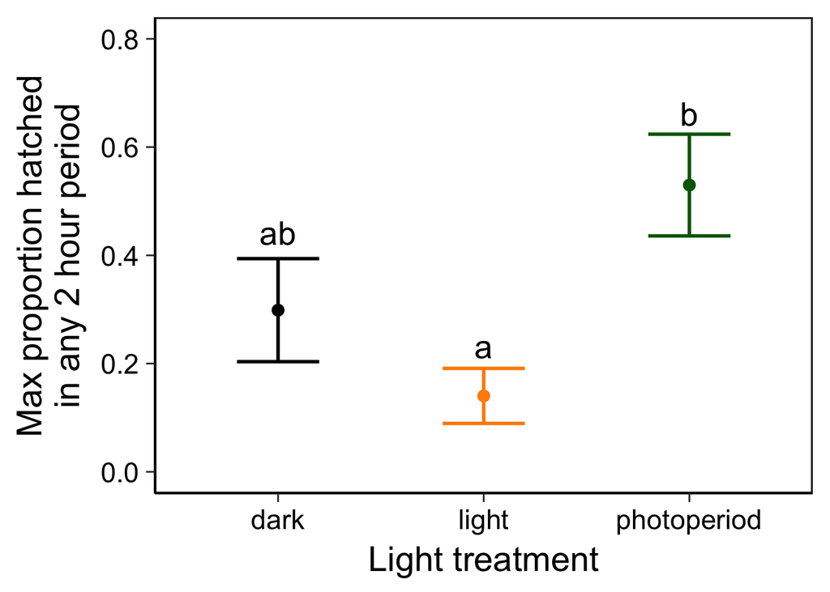

```r
library(ggplot2)
library(scales)

legend_title="Light \ntreatment" #make legend title here

g = ggplot(data=synch_sum, aes(x= treatment, y= mean_diff)) +
  geom_point(aes(color= treatment), size= 3) +
  geom_errorbar(aes(ymin=mean_diff-SE, ymax=mean_diff+SE, color = treatment), width= .4, size= 1) +
  labs(y="Max proportion hatched\nin any 2 hour period", x="Light treatment") +
  scale_y_continuous(limits=c(0,0.8),oob = rescale_none, breaks= pretty_breaks(n=4)) +
  scale_x_discrete(limits= c("dark", "light", "photoperiod")) + # put the x axis stuff in order that I want.
  scale_color_manual(legend_title,values = c("black", "darkorange", "darkgreen")) +
  geom_text(aes(y = c(0.42, 0.21, 0.64), label = c("ab", "a", "b")), position = position_dodge(width = .8), color= "black", vjust = 0, size = 7) +
  theme_classic(base_size = 21) +
  theme(panel.background = element_rect(colour = "black", size=1), legend.position = "none", axis.text.x = element_text(color="black"), axis.text.y = element_text(color="black"))
g
```

## **SYNCHRONY ACROSS CLUTCHES** TRIAL

```r
library(dplyr)
df = photopattern %>%
  group_by(clutch, treatment) %>%
  mutate(twohour = percentage - lag(percentage, n= 2,  default = 0), maximum=max(twohour)) %>% #this creates new column with differences of lagged percentages by clutch for four hour periods
  filter(twohour == maximum) %>% # include only the maximum values
  arrange(clutch) %>%
  dplyr::select(clutch, treatment, age, percentage,twohour, maximum) %>%
  filter(age==min(age)) # leave initial ages with max prop hatching in 4 hours
df
```

```
## # A tibble: 33 x 6
## # Groups:   clutch, treatment [33]
##    clutch   treatment      age percentage   twohour   maximum
##     <int>      <fctr>    <dbl>      <dbl>     <dbl>     <dbl>
##  1    221 photoperiod 5.833333        0.9 0.5000000 0.5000000
##  2    221        dark 6.000000        1.0 0.4000000 0.4000000
##  3    221       light 6.000000        1.0 0.4000000 0.4000000
##  4    222 photoperiod 5.833333        1.0 1.0000000 1.0000000
##  5    222        dark 6.000000        1.0 0.8571429 0.8571429
##  6    222       light 6.166667        1.0 0.5714286 0.5714286
##  7    230 photoperiod 5.833333        1.0 0.7000000 0.7000000
##  8    230        dark 6.000000        0.9 0.9000000 0.9000000
##  9    230       light 6.000000        0.7 0.5000000 0.5000000
## 10    231       light 5.833333        0.3 0.3000000 0.3000000
## # ... with 23 more rows
```

### Visualization

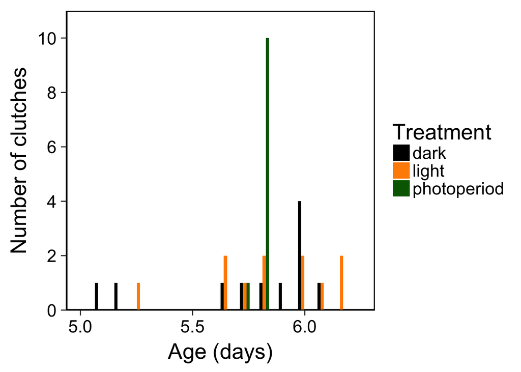

```r
library(ggplot2)
library(scales)

legend_title="Treatment" #make legend title here

g= ggplot(data=df, aes(x=age, fill=treatment)) +
  geom_histogram(position= "dodge")+
  labs(y="Number of clutches", x="Age (days)") +
  scale_y_continuous(limits=c(0,11), expand = c(0, 0), oob = rescale_none, breaks= pretty_breaks(n=5)) + # expand thing forces it to start at 0
  scale_x_continuous(limits=c(5,6.25), breaks= pretty_breaks(n=4)) +
  scale_fill_manual(legend_title,values = c("black", "darkorange", "darkgreen")) +
  theme_classic(base_size = 21) +
  theme(panel.background = element_rect(colour = "black", size=1), axis.text.x = element_text(color="black"), axis.text.y = element_text(color="black")) # this creates border around whole thing
g
```

### Stats: Kurtosis value for dist. of ages of maximum hatching in 4h period for each treatment

```r
library(e1071)
library(moments)
dark_synch= df %>%
  filter(treatment == "dark")
dark_synch
```

```
## # A tibble: 11 x 6
## # Groups:   clutch, treatment [11]
##    clutch treatment      age percentage   twohour   maximum
##     <int>    <fctr>    <dbl>      <dbl>     <dbl>     <dbl>
##  1    221      dark 6.000000  1.0000000 0.4000000 0.4000000
##  2    222      dark 6.000000  1.0000000 0.8571429 0.8571429
##  3    230      dark 6.000000  0.9000000 0.9000000 0.9000000
##  4    231      dark 6.000000  0.6000000 0.6000000 0.6000000
##  5    232      dark 5.166667  1.0000000 0.9000000 0.9000000
##  6    233      dark 5.083333  0.5000000 0.4000000 0.4000000
##  7    234      dark 5.916667  0.8000000 0.8000000 0.8000000
##  8    235      dark 5.833333  0.8000000 0.8000000 0.8000000
##  9    236      dark 5.750000  0.8000000 0.2000000 0.2000000
## 10    239      dark 6.083333  0.7142857 0.5714286 0.5714286
## 11    240      dark 5.666667  1.0000000 1.0000000 1.0000000
```

```r
light_synch= df %>%
  filter(treatment == "light")
light_synch
```

```
## # A tibble: 11 x 6
## # Groups:   clutch, treatment [11]
##    clutch treatment      age percentage   twohour   maximum
##     <int>    <fctr>    <dbl>      <dbl>     <dbl>     <dbl>
##  1    221     light 6.000000  1.0000000 0.4000000 0.4000000
##  2    222     light 6.166667  1.0000000 0.5714286 0.5714286
##  3    230     light 6.000000  0.7000000 0.5000000 0.5000000
##  4    231     light 5.833333  0.3000000 0.3000000 0.3000000
##  5    232     light 5.750000  0.8000000 0.5000000 0.5000000
##  6    233     light 5.666667  0.6000000 0.6000000 0.6000000
##  7    234     light 6.166667  0.4000000 0.4000000 0.4000000
##  8    235     light 5.250000  0.4000000 0.3000000 0.3000000
##  9    236     light 5.666667  0.6000000 0.3000000 0.3000000
## 10    239     light 6.083333  0.8571429 0.4285714 0.4285714
## 11    240     light 5.833333  0.8571429 0.7142857 0.7142857
```

```r
photo_synch= df %>%
  filter(treatment == "photoperiod")
photo_synch
```

```
## # A tibble: 11 x 6
## # Groups:   clutch, treatment [11]
##    clutch   treatment      age percentage   twohour   maximum
##     <int>      <fctr>    <dbl>      <dbl>     <dbl>     <dbl>
##  1    221 photoperiod 5.833333        0.9 0.5000000 0.5000000
##  2    222 photoperiod 5.833333        1.0 1.0000000 1.0000000
##  3    230 photoperiod 5.833333        1.0 0.7000000 0.7000000
##  4    231 photoperiod 5.833333        0.8 0.8000000 0.8000000
##  5    232 photoperiod 5.833333        1.0 0.3000000 0.3000000
##  6    233 photoperiod 5.833333        1.0 0.4000000 0.4000000
##  7    234 photoperiod 5.833333        1.0 0.7000000 0.7000000
##  8    235 photoperiod 5.833333        1.0 0.8571429 0.8571429
##  9    236 photoperiod 5.833333        1.0 0.7000000 0.7000000
## 10    239 photoperiod 5.750000        1.0 0.8571429 0.8571429
## 11    240 photoperiod 5.833333        1.0 1.0000000 1.0000000
```

```r
kurtosis(dark_synch$age)
```

```
## [1] 3.003346
```

```r
kurtosis(light_synch$age)
```

```
## [1] 3.232073
```

```r
kurtosis(photo_synch$age)
```

```
## [1] 9.1
```

- dark == 3.003346
- light == 3.232073
- photoperiod == 9.1

### Levene Test for Homogeneity of Variance

```r
dark_light = df %>%
  filter(treatment == "light" | treatment == "dark")
dark_light
```

```
## # A tibble: 22 x 6
## # Groups:   clutch, treatment [22]
##    clutch treatment      age percentage   twohour   maximum
##     <int>    <fctr>    <dbl>      <dbl>     <dbl>     <dbl>
##  1    221      dark 6.000000        1.0 0.4000000 0.4000000
##  2    221     light 6.000000        1.0 0.4000000 0.4000000
##  3    222      dark 6.000000        1.0 0.8571429 0.8571429
##  4    222     light 6.166667        1.0 0.5714286 0.5714286
##  5    230      dark 6.000000        0.9 0.9000000 0.9000000
##  6    230     light 6.000000        0.7 0.5000000 0.5000000
##  7    231     light 5.833333        0.3 0.3000000 0.3000000
##  8    231      dark 6.000000        0.6 0.6000000 0.6000000
##  9    232      dark 5.166667        1.0 0.9000000 0.9000000
## 10    232     light 5.750000        0.8 0.5000000 0.5000000
## # ... with 12 more rows
```

```r
photo_dark = df %>%
  filter(treatment == "photoperiod" | treatment == "dark")
photo_dark
```

```
## # A tibble: 22 x 6
## # Groups:   clutch, treatment [22]
##    clutch   treatment      age percentage   twohour   maximum
##     <int>      <fctr>    <dbl>      <dbl>     <dbl>     <dbl>
##  1    221 photoperiod 5.833333        0.9 0.5000000 0.5000000
##  2    221        dark 6.000000        1.0 0.4000000 0.4000000
##  3    222 photoperiod 5.833333        1.0 1.0000000 1.0000000
##  4    222        dark 6.000000        1.0 0.8571429 0.8571429
##  5    230 photoperiod 5.833333        1.0 0.7000000 0.7000000
##  6    230        dark 6.000000        0.9 0.9000000 0.9000000
##  7    231 photoperiod 5.833333        0.8 0.8000000 0.8000000
##  8    231        dark 6.000000        0.6 0.6000000 0.6000000
##  9    232        dark 5.166667        1.0 0.9000000 0.9000000
## 10    232 photoperiod 5.833333        1.0 0.3000000 0.3000000
## # ... with 12 more rows
```

```r
photo_light = df %>%
  filter(treatment == "photoperiod" | treatment == "light")
photo_light
```

```
## # A tibble: 22 x 6
## # Groups:   clutch, treatment [22]
##    clutch   treatment      age percentage   twohour   maximum
##     <int>      <fctr>    <dbl>      <dbl>     <dbl>     <dbl>
##  1    221 photoperiod 5.833333        0.9 0.5000000 0.5000000
##  2    221       light 6.000000        1.0 0.4000000 0.4000000
##  3    222 photoperiod 5.833333        1.0 1.0000000 1.0000000
##  4    222       light 6.166667        1.0 0.5714286 0.5714286
##  5    230 photoperiod 5.833333        1.0 0.7000000 0.7000000
##  6    230       light 6.000000        0.7 0.5000000 0.5000000
##  7    231       light 5.833333        0.3 0.3000000 0.3000000
##  8    231 photoperiod 5.833333        0.8 0.8000000 0.8000000
##  9    232       light 5.750000        0.8 0.5000000 0.5000000
## 10    232 photoperiod 5.833333        1.0 0.3000000 0.3000000
## # ... with 12 more rows
```

```r
#overall:
leveneTest(data=df, age~treatment)
```

```
## Levene's Test for Homogeneity of Variance (center = median)
##       Df F value  Pr(>F)
## group  2  4.6012 0.01808 *
##       30
## ---
## Signif. codes:  0 '***' 0.001 '**' 0.01 '*' 0.05 '.' 0.1 ' ' 1
```

```r
#dark vs light
leveneTest(data=dark_light, age~treatment)
```

```
## Levene's Test for Homogeneity of Variance (center = median)
##       Df F value Pr(>F)
## group  1   0.093 0.7635
##       20
```

```r
#photo vs dark
leveneTest(data=photo_dark, age~treatment)
```

```
## Levene's Test for Homogeneity of Variance (center = median)
##       Df F value  Pr(>F)
## group  1  7.0203 0.01538 *
##       20
## ---
## Signif. codes:  0 '***' 0.001 '**' 0.01 '*' 0.05 '.' 0.1 ' ' 1
```

```r
#photo vs light
leveneTest(data=photo_light, age~treatment)
```

```
## Levene's Test for Homogeneity of Variance (center = median)
##       Df F value   Pr(>F)
## group  1   14.76 0.001018 **
##       20
## ---
## Signif. codes:  0 '***' 0.001 '**' 0.01 '*' 0.05 '.' 0.1 ' ' 1
```

## **EARLY HATCHING in DARK treatment**

```r
head(photopattern)
```

```
##       date clutch treatment age_days  age time.of.day time time_group
## 1 20150804    221      dark        4 4.25           6    0          1
## 2 20150804    222      dark        4 4.25           6    0          1
## 3 20150804    230      dark        4 4.25           6    0          1
## 4 20150804    231      dark        4 4.25           6    0          1
## 5 20150804    232      dark        4 4.25           6    0          1
## 6 20150804    233      dark        4 4.25           6    0          1
##   intial...eggs total_hatched H NH percentage notes
## 1            10             0 0 10          0
## 2             7             0 0  7          0
## 3            10             0 0 10          0
## 4            10             0 0 10          0
## 5            10             0 0 10          0
## 6            10             0 0 10          0
```

```r
early = photopattern %>%
  group_by(treatment) %>%
  filter(age == 5.75)
early
```

```
## # A tibble: 33 x 14
## # Groups:   treatment [3]
##        date clutch treatment age_days   age time.of.day  time time_group
##       <int>  <int>    <fctr>    <int> <dbl>       <int> <int>      <int>
##  1 20150805    221      dark        5  5.75          18    36          7
##  2 20150805    222      dark        5  5.75          18    36          7
##  3 20150805    230      dark        5  5.75          18    36          7
##  4 20150805    231      dark        5  5.75          18    36          7
##  5 20150805    232      dark        5  5.75          18    36          7
##  6 20150805    233      dark        5  5.75          18    36          7
##  7 20150805    234      dark        5  5.75          18    36          7
##  8 20150805    235      dark        5  5.75          18    36          7
##  9 20150805    236      dark        5  5.75          18    36          7
## 10 20150805    239      dark        5  5.75          18    36          7
## # ... with 23 more rows, and 6 more variables: intial...eggs <int>,
## #   total_hatched <int>, H <int>, NH <int>, percentage <dbl>, notes <fctr>
```

```r
test1 = early %>%
  group_by(treatment) %>%
  summarise(mean= mean(percentage), SE= sd(percentage)/sqrt(length(percentage)), sample_size=n())
test1
```

```
## # A tibble: 3 x 4
##     treatment      mean         SE sample_size
##        <fctr>     <dbl>      <dbl>       <int>
## 1        dark 0.4402597 0.13274354          11
## 2       light 0.4493506 0.07908014          11
## 3 photoperiod 0.4428571 0.10068412          11
```

Stats

```r
m=lm(data=early, percentage~treatment)
summary(m)
```

```
##
## Call:
## lm(formula = percentage ~ treatment, data = early)
##
## Residuals:
##      Min       1Q   Median       3Q      Max
## -0.44935 -0.29740 -0.04026  0.35065  0.55974
##
## Coefficients:
##                      Estimate Std. Error t value Pr(>|t|)
## (Intercept)          0.440260   0.106477   4.135 0.000263 ***
## treatmentlight       0.009091   0.150581   0.060 0.952259
## treatmentphotoperiod 0.002597   0.150581   0.017 0.986352
## ---
## Signif. codes:  0 '***' 0.001 '**' 0.01 '*' 0.05 '.' 0.1 ' ' 1
##
## Residual standard error: 0.3531 on 30 degrees of freedom
## Multiple R-squared:  0.0001289,  Adjusted R-squared:  -0.06653
## F-statistic: 0.001934 on 2 and 30 DF,  p-value: 0.9981
```

```r
library(car)
Anova(m)
```

```
## Anova Table (Type II tests)
##
## Response: percentage
##           Sum Sq Df F value Pr(>F)
## treatment 0.0005  2  0.0019 0.9981
## Residuals 3.7413 30
```

```r
aov(m)
```

```
## Call:
##    aov(formula = m)
##
## Terms:
##                 treatment Residuals
## Sum of Squares   0.000482  3.741299
## Deg. of Freedom         2        30
##
## Residual standard error: 0.353143
## Estimated effects may be unbalanced
```

```r
summary(aov(m))
```

```
##             Df Sum Sq Mean Sq F value Pr(>F)
## treatment    2  0.000 0.00024   0.002  0.998
## Residuals   30  3.741 0.12471
```

```r
#post hoc
TukeyHSD(aov(m))
```

```
##   Tukey multiple comparisons of means
##     95% family-wise confidence level
##
## Fit: aov(formula = m)
##
## $treatment
##                           diff        lwr       upr     p adj
## light-dark         0.009090909 -0.3621313 0.3803131 0.9979927
## photoperiod-dark   0.002597403 -0.3686248 0.3738196 0.9998360
## photoperiod-light -0.006493507 -0.3777157 0.3647287 0.9989753
```

- F value == 0.0019; df= 2,30
- overall treatment **p-value** == 0.9981 **NS**
- light-dark **p-value** == 0.9979927 **NS**
- photo-dark **p-value** == 0.9998360 **NS**
- photo-light **p-value** == 0.9989753 **NS**

> interpretation: **proportion** hatched after at 5.75 days old; same in all treatments…. dark does not elicit early hatching…

Check for normality

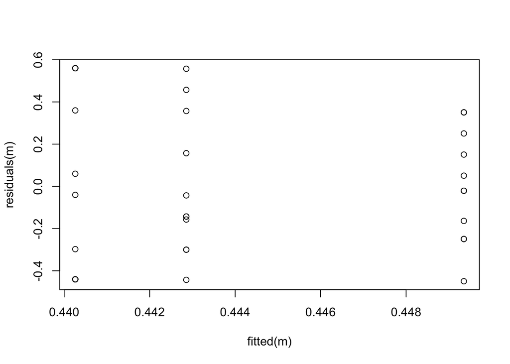

```r
plot(fitted(m), residuals(m))
```

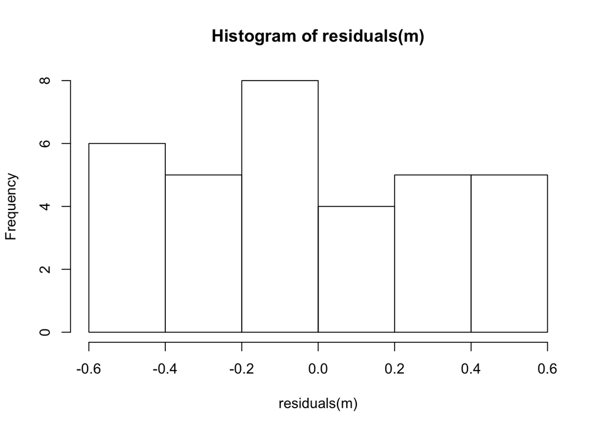

```r
hist(residuals(m))
```

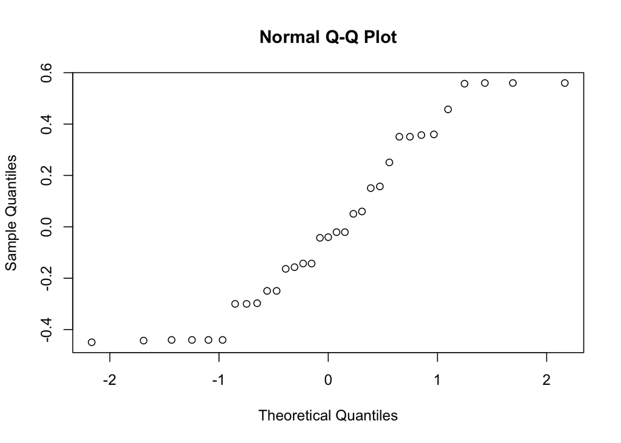

```r
qqnorm(residuals(m))
```

```r
shapiro.test(m$residuals)
```

```
##
##  Shapiro-Wilk normality test
##
## data:  m$residuals
## W = 0.91724, p-value = 0.01537
```

- shapiro test **p-value** == 0.01537

***NOT normally distributed** so stats are NOT good….

```r
library(FSA)
kwt=kruskal.test(data=early, percentage~as.factor(treatment))
kwt
```

```
##
##  Kruskal-Wallis rank sum test
##
## data:  percentage by as.factor(treatment)
## Kruskal-Wallis chi-squared = 0.096347, df = 2, p-value = 0.953
```

```r
dunnTest(data=early, percentage~as.factor(treatment), method = "bh")
```

```
## Dunn (1964) Kruskal-Wallis multiple comparison
```

```
##   p-values adjusted with the Benjamini-Hochberg method.
```

```
##            Comparison          Z   P.unadj     P.adj
## 1        dark - light -0.3103982 0.7562582 1.0000000
## 2  dark - photoperiod -0.1551991 0.8766644 0.8766644
## 3 light - photoperiod  0.1551991 0.8766644 1.0000000
```

- X^2 == 0.096347
- overall treatment **p-value** == 0.953 **NS**
- light-dark **p-value** == 1.0000000 **NS**
- photo-dark **p-value** == 0.8766644 **NS**
- photo-light **p-value** == 1.0000000 **NS**

> interpretation: prop hatched at 5.75 days old not different at all…. darkness does not induce early hatching

## **HATCHING after day 6 (LATE hatching in LIGHT treatment)**

```r
head(photopattern)
```

```
##       date clutch treatment age_days  age time.of.day time time_group
## 1 20150804    221      dark        4 4.25           6    0          1
## 2 20150804    222      dark        4 4.25           6    0          1
## 3 20150804    230      dark        4 4.25           6    0          1
## 4 20150804    231      dark        4 4.25           6    0          1
## 5 20150804    232      dark        4 4.25           6    0          1
## 6 20150804    233      dark        4 4.25           6    0          1
##   intial...eggs total_hatched H NH percentage notes
## 1            10             0 0 10          0
## 2             7             0 0  7          0
## 3            10             0 0 10          0
## 4            10             0 0 10          0
## 5            10             0 0 10          0
## 6            10             0 0 10          0
```

```r
delay = photopattern %>%
  group_by(treatment) %>%
  filter(time == 42) %>%
  mutate(prop_hatched=1-percentage)
delay
```

```
## # A tibble: 33 x 15
## # Groups:   treatment [3]
##        date clutch treatment age_days   age time.of.day  time time_group
##       <int>  <int>    <fctr>    <int> <dbl>       <int> <int>      <int>
##  1 20150806    221      dark        6     6           0    42          8
##  2 20150806    222      dark        6     6           0    42          8
##  3 20150806    230      dark        6     6           0    42          8
##  4 20150806    231      dark        6     6           0    42          8
##  5 20150806    232      dark        6     6           0    42          8
##  6 20150806    233      dark        6     6           0    42          8
##  7 20150806    234      dark        6     6           0    42          8
##  8 20150806    235      dark        6     6           0    42          8
##  9 20150806    236      dark        6     6           0    42          8
## 10 20150806    239      dark        6     6           0    42          8
## # ... with 23 more rows, and 7 more variables: intial...eggs <int>,
## #   total_hatched <int>, H <int>, NH <int>, percentage <dbl>,
## #   notes <fctr>, prop_hatched <dbl>
```

```r
test = delay %>%
  group_by(treatment) %>%
  summarise(mean= mean(prop_hatched), SE= sd(prop_hatched)/sqrt(length(prop_hatched)), sample_size=n())
test
```

```
## # A tibble: 3 x 4
##     treatment       mean         SE sample_size
##        <fctr>      <dbl>      <dbl>       <int>
## 1        dark 0.10259740 0.05026159          11
## 2       light 0.33506494 0.09037879          11
## 3 photoperiod 0.02727273 0.01949783          11
```

Stats

```r
m=lm(data=delay, prop_hatched~treatment)
summary(m)
```

```
##
## Call:
## lm(formula = prop_hatched ~ treatment, data = delay)
##
## Residuals:
##      Min       1Q   Median       3Q      Max
## -0.33506 -0.10260 -0.02727  0.07273  0.66494
##
## Coefficients:
##                      Estimate Std. Error t value Pr(>|t|)
## (Intercept)           0.10260    0.06076   1.689   0.1017
## treatmentlight        0.23247    0.08593   2.705   0.0111 *
## treatmentphotoperiod -0.07532    0.08593  -0.877   0.3877
## ---
## Signif. codes:  0 '***' 0.001 '**' 0.01 '*' 0.05 '.' 0.1 ' ' 1
##
## Residual standard error: 0.2015 on 30 degrees of freedom
## Multiple R-squared:  0.3173, Adjusted R-squared:  0.2718
## F-statistic: 6.973 on 2 and 30 DF,  p-value: 0.003258
```

```r
library(car)
Anova(m)
```

```
## Anova Table (Type II tests)
##
## Response: prop_hatched
##            Sum Sq Df F value   Pr(>F)
## treatment 0.56632  2  6.9731 0.003258 **
## Residuals 1.21822 30
## ---
## Signif. codes:  0 '***' 0.001 '**' 0.01 '*' 0.05 '.' 0.1 ' ' 1
```

```r
aov(m)
```

```
## Call:
##    aov(formula = m)
##
## Terms:
##                 treatment Residuals
## Sum of Squares  0.5663203 1.2182189
## Deg. of Freedom         2        30
##
## Residual standard error: 0.2015125
## Estimated effects may be unbalanced
```

```r
summary(aov(m))
```

```
##             Df Sum Sq Mean Sq F value  Pr(>F)
## treatment    2 0.5663 0.28316   6.973 0.00326 **
## Residuals   30 1.2182 0.04061
## ---
## Signif. codes:  0 '***' 0.001 '**' 0.01 '*' 0.05 '.' 0.1 ' ' 1
```

```r
#post hoc
TukeyHSD(aov(m))
```

```
##   Tukey multiple comparisons of means
##     95% family-wise confidence level
##
## Fit: aov(formula = m)
##
## $treatment
##                          diff         lwr         upr     p adj
## light-dark         0.23246753  0.02063853  0.44429653 0.0291367
## photoperiod-dark  -0.07532468 -0.28715367  0.13650432 0.6589382
## photoperiod-light -0.30779221 -0.51962121 -0.09596321 0.0033054
```

- F value == 6.9731; df==2,30
- overall treatment **p-value** == 0.003258 **
- light-dark **p-value** == 0.0291367 *
- photo-dark **p-value** == 0.6589382 **NS**
- photo-light **p-value** == 0.0033054 **

> interpretation: **proportion** hatched after 6 days old; more embryos hatched after 6 d in light than in other treatments

Check for normality

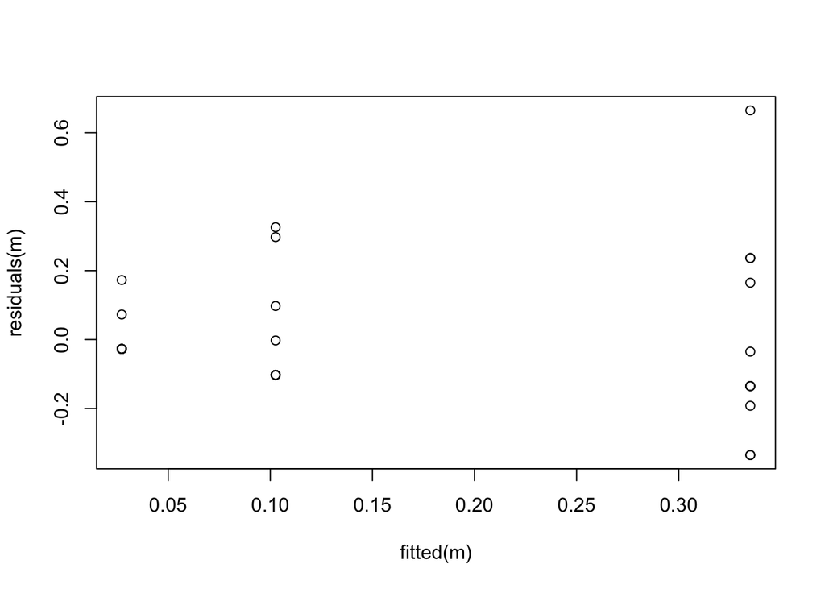

```r
plot(fitted(m), residuals(m))
```

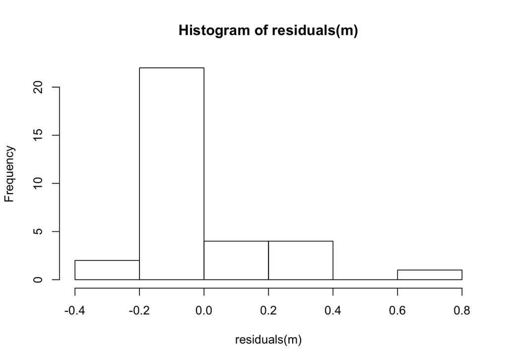

```r
hist(residuals(m))
```

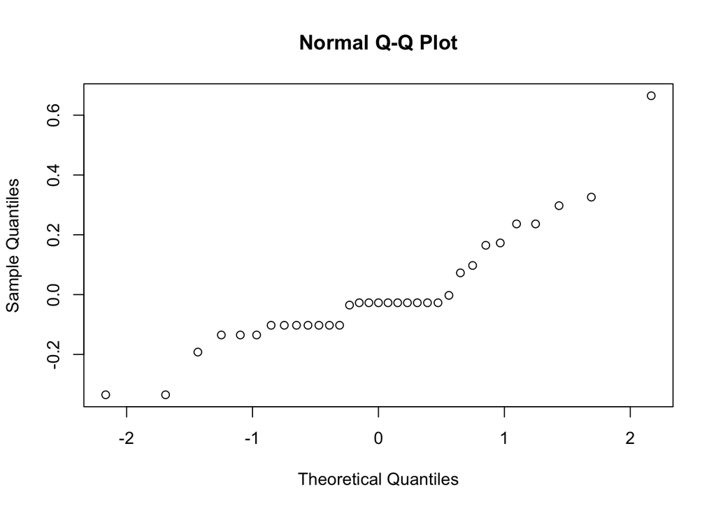

```r
qqnorm(residuals(m))
```

```r
shapiro.test(m$residuals)
```

```
##
##  Shapiro-Wilk normality test
##
## data:  m$residuals
## W = 0.87619, p-value = 0.001358
```

- shapiro test **p-value** == 0.001358

***NOT normally distributed** so stats are NOT good….

```r
library(FSA)
kwt=kruskal.test(data=delay, prop_hatched~as.factor(treatment))
kwt
```

```
##
##  Kruskal-Wallis rank sum test
##
## data:  prop_hatched by as.factor(treatment)
## Kruskal-Wallis chi-squared = 11.476, df = 2, p-value = 0.003222
```

```r
dunnTest(data=delay, prop_hatched~as.factor(treatment), method = "bh")
```

```
## Dunn (1964) Kruskal-Wallis multiple comparison
```

```
##   p-values adjusted with the Benjamini-Hochberg method.
```

```
##            Comparison          Z     P.unadj       P.adj
## 1        dark - light -2.3655054 0.018005482 0.027008223
## 2  dark - photoperiod  0.9172368 0.359018578 0.359018578
## 3 light - photoperiod  3.2827422 0.001028026 0.003084079
```

- X^2 == 11.476
- overall treatment **p-value** == 0.003222 **
- light-dark **p-value** == 0.027008223 *
- photo-dark **p-value** == 0.359018578 **NS**
- photo-light **p-value** == 0.003084079 **

> interpretation: **number of embryos** hatched after 6 days old; more embryos hatched after 6 d in light than in other treatments

### Visualization

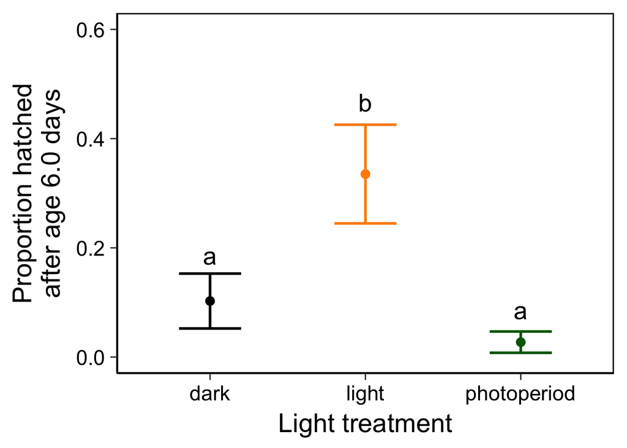

```r
legend_title="Light \ntreatment" #make legend title here

g = ggplot(data=test, aes(x= treatment, y= mean)) +
  geom_point(aes(color= treatment), size= 3) +
  geom_errorbar(aes(ymin=mean-SE, ymax=mean+SE, color = treatment), width= .4, size= 1) +
  labs(y="Proportion hatched\nafter age 6.0 days", x="Light treatment") +
  scale_y_continuous(limits=c(0,0.6),oob = rescale_none, breaks= pretty_breaks(n=4)) +
  scale_x_discrete(limits= c("dark", "light", "photoperiod")) + # put the x axis stuff in order that I want.
  scale_color_manual(legend_title,values = c("black", "darkorange", "darkgreen")) +
  geom_text(aes(y = c(.17, .45, .07), label = c("a", "b", "a")), position = position_dodge(width = .8), color= "black", vjust = 0, size = 7) +
  theme_classic(base_size = 21) +
  theme(panel.background = element_rect(colour = "black", size=1), legend.position = "none", axis.text.x = element_text(color="black"), axis.text.y = element_text(color="black"))
g
```

# **Hatching Orientation Experiment Data Analysis**

## Data importing

First, we can load this straight from my computer as follows…

```r
#library(readxl)
#phototaxis <- read_excel("/Volumes/EggScience 1/Warkentin Lab/2015 Data/Hatching Phototaxis Data/Hatching Orientation Data.xlsx", sheet = "phototaxis")

#str(phototaxis) #structure of the data; column names, etc.
#head(phototaxis) #preview the data
```

Or, anyone can access this dataset from my personal Github repository as follows:

```r
library(curl)
f <- curl("https://raw.githubusercontent.com/bguell/Light-Cue-Manuscript-Final/master/Hatching%20Orientation%20Data.csv")
phototaxis <- read.csv(f, header = TRUE, sep = ",", stringsAsFactors = TRUE)
head(phototaxis)
```

```
##       date test.number experiment age clutch start.time Position.Entered
## 1 20150705           1      trial  4d     89     2:05pm
## 2 20150705           2      trial  4d     89     2:20pm
## 3 20150705           3      trial  4d     90     2:33pm
## 4 20150705           4      trial  4d     90     2:47pm
## 5 20150705           5      trial  4d     84     3:05pm
## 6 20150705           7      trial  4d     91     3:45pm
##   HT..min.w.out.sec. HT..sec. Hatching.Time..min. Hatching.direction
## 1                 10       41               10.68              light
## 2                  8       21                8.35              light
## 3                  8       36                8.60              light
## 4                 11       51               11.85              light
## 5                 10       54               10.90               dark
## 6                 24       48               24.80               dark
```

## 4d Hatching Complications Analysis

```r
prop.test(x=182, n=189, p=.025)
```

```
##
##  1-sample proportions test with continuity correction
##
## data:  182 out of 189, null probability 0.025
## X-squared = 6783.2, df = 1, p-value < 2.2e-16
## alternative hypothesis: true p is not equal to 0.025
## 95 percent confidence interval:
##  0.9221099 0.9836749
## sample estimates:
##        p
## 0.962963
```

- **X^2** == 6783.2
- **p-value** < 2.2e-16

```r
prop.test(x=182, n=189, p=.050)
```

```
##
##  1-sample proportions test with continuity correction
##
## data:  182 out of 189, null probability 0.05
## X-squared = 3297.3, df = 1, p-value < 2.2e-16
## alternative hypothesis: true p is not equal to 0.05
## 95 percent confidence interval:
##  0.9221099 0.9836749
## sample estimates:
##        p
## 0.962963
```

- **X^2** == 3297.3
- **p-value** < 2.2e-16

### Jelly whole clutch vs open water individual cup

Two Sided:

```r
prop.test(x=6,n=21,p=.032)
```

```
##
##  1-sample proportions test with continuity correction
##
## data:  6 out of 21, null probability 0.032
## X-squared = 35.834, df = 1, p-value = 2.149e-09
## alternative hypothesis: true p is not equal to 0.032
## 95 percent confidence interval:
##  0.1219497 0.5231442
## sample estimates:
##         p
## 0.2857143
```

- **X^2** == 35.834
- **p-value** == 2.149e-09

One Sided:

```r
prop.test(x=6,n=21,p=.032, alternative = "greater")
```

```
##
##  1-sample proportions test with continuity correction
##
## data:  6 out of 21, null probability 0.032
## X-squared = 35.834, df = 1, p-value = 1.075e-09
## alternative hypothesis: true p is greater than 0.032
## 95 percent confidence interval:
##  0.1380781 1.0000000
## sample estimates:
##         p
## 0.2857143
```

## Phototaxis Analysis

> Note: Here, for all tests, we are testing the null hypothesis that the proportions of hatching direction was random (i.e. 50% to each side)

Control experiment

```r
prop.test(9,20)
```

```
##
##  1-sample proportions test with continuity correction
##
## data:  9 out of 20, null probability 0.5
## X-squared = 0.05, df = 1, p-value = 0.8231
## alternative hypothesis: true p is not equal to 0.5
## 95 percent confidence interval:
##  0.2382855 0.6795196
## sample estimates:
##    p
## 0.45
```

- **X^2** == 0.05
- **p-value** == 0.8231

Iteration 1: First set of trials:

```r
prop.test(30,45)
```

```
##
##  1-sample proportions test with continuity correction
##
## data:  30 out of 45, null probability 0.5
## X-squared = 4.3556, df = 1, p-value = 0.03689
## alternative hypothesis: true p is not equal to 0.5
## 95 percent confidence interval:
##  0.5094948 0.7956005
## sample estimates:
##         p
## 0.6666667
```

- **X^2** == 4.3556
- **p-value** == 0.03689

Iteration 2: Second set of trials:

```r
prop.test(29,40)
```

```
##
##  1-sample proportions test with continuity correction
##
## data:  29 out of 40, null probability 0.5
## X-squared = 7.225, df = 1, p-value = 0.00719
## alternative hypothesis: true p is not equal to 0.5
## 95 percent confidence interval:
##  0.5586198 0.8485840
## sample estimates:
##     p
## 0.725
```

- **X^2** == 7.225
- **p-value** == 0.00719

Comparison of two trials:

```r
prop.test(x=c(29,40), n=c(30,45))
```

```
##
##  2-sample test for equality of proportions with continuity
##  correction
##
## data:  c(29, 40) out of c(30, 45)
## X-squared = 0.61141, df = 1, p-value = 0.4343
## alternative hypothesis: two.sided
## 95 percent confidence interval:
##  -0.0620589  0.2176145
## sample estimates:
##    prop 1    prop 2
## 0.9666667 0.8888889
```

- **X^2** == 0.61141
- **p-value** == 0.4343

Since the two sets are data are not significantly different from each other, I’ve pooled the data and run the test on the whole combined set…

Pooled analysis:

```r
prop.test(59,85)
```

```
##
##  1-sample proportions test with continuity correction
##
## data:  59 out of 85, null probability 0.5
## X-squared = 12.047, df = 1, p-value = 0.0005187
## alternative hypothesis: true p is not equal to 0.5
## 95 percent confidence interval:
##  0.5834316 0.7870343
## sample estimates:
##         p
## 0.6941176
```

- **X^2** == 12.047
- **p-value** == 0.0005187

## GLMMs

> I created these following models using a GLMM where the “hatching direction” data is the response variable and the side of insertion data as the predictor variable. I also added clutch as a random effect in these models. The models will be run using a **binomial family distribution**, and all follow a **logit link function** of correction. Again we will obtain a p-value using LRTs.

```r
#some data adjustment so model can run properly
phototaxis$Hatching.direction = as.factor(phototaxis$Hatching.direction)
phototaxis$test.number = as.character(phototaxis$test.number)

#the models:
p1=glmer(Hatching.direction ~  Position.Entered + (1|clutch), data=phototaxis, family="binomial")
summary(p1)
```

```
## Generalized linear mixed model fit by maximum likelihood (Laplace
##   Approximation) [glmerMod]
##  Family: binomial  ( logit )
## Formula: Hatching.direction ~ Position.Entered + (1 | clutch)
##    Data: phototaxis
##
##      AIC      BIC   logLik deviance df.resid
##    142.1    152.7    -67.0    134.1      101
##
## Scaled residuals:
##     Min      1Q  Median      3Q     Max
## -1.7050 -1.1560  0.5865  0.7480  0.9512
##
## Random effects:
##  Groups Name        Variance Std.Dev.
##  clutch (Intercept) 0.2336   0.4834
## Number of obs: 105, groups:  clutch, 44
##
## Fixed effects:
##                       Estimate Std. Error z value Pr(>|z|)
## (Intercept)             0.3571     0.3727   0.958    0.338
## Position.Entereddark    0.7162     0.5483   1.306    0.192
## Position.Enteredlight   0.2296     0.5298   0.434    0.665
##
## Correlation of Fixed Effects:
##             (Intr) Pstn.Entrdd
## Pstn.Entrdd -0.632
## Pstn.Entrdl -0.677  0.480
```

```r
# make a second, simpler model without our variable of interest:
p2=glmer(Hatching.direction ~ (1|clutch), data=phototaxis, family="binomial")
summary(p2)
```

```
## Generalized linear mixed model fit by maximum likelihood (Laplace
##   Approximation) [glmerMod]
##  Family: binomial  ( logit )
## Formula: Hatching.direction ~ (1 | clutch)
##    Data: phototaxis
##
##      AIC      BIC   logLik deviance df.resid
##    139.8    145.2    -67.9    135.8      103
##
## Scaled residuals:
##     Min      1Q  Median      3Q     Max
## -1.4535 -1.1703  0.6560  0.7163  0.8701
##
## Random effects:
##  Groups Name        Variance Std.Dev.
##  clutch (Intercept) 0.3009   0.5485
## Number of obs: 105, groups:  clutch, 44
##
## Fixed effects:
##             Estimate Std. Error z value Pr(>|z|)
## (Intercept)   0.6622     0.2462   2.689  0.00716 **
## ---
## Signif. codes:  0 '***' 0.001 '**' 0.01 '*' 0.05 '.' 0.1 ' ' 1
```

### Model comparison using **Likelihood Ratio Tests (LRT)**

### GLM EFFECT OF INSERTION SIDE ON HATCHING DIRECTION

```r
anova(p2, p1)
```

```
## Data: phototaxis
## Models:
## p2: Hatching.direction ~ (1 | clutch)
## p1: Hatching.direction ~ Position.Entered + (1 | clutch)
##    Df    AIC    BIC  logLik deviance  Chisq Chi Df Pr(>Chisq)
## p2  2 139.85 145.16 -67.925   135.85
## p1  4 142.05 152.67 -67.025   134.05 1.7988      2     0.4068
```

- **p-value** == 0.4068 **NS**

Here we can clearly see that there was no significant effect of position entered on hatching direction

Again, we can use the Anova() function for Wald chi-square tests with one function…

```r
library(car)
Anova(p1)
```

```
## Analysis of Deviance Table (Type II Wald chisquare tests)
##
## Response: Hatching.direction
##                   Chisq Df Pr(>Chisq)
## Position.Entered 1.7546  2     0.4159
```

- **p-value** == 0.4159 **NS**

And we see the same exact results. Thus we will **report results from the LRT** in our manuscript.

### Visualization of Hatching Orientation Experiment

First a simple barplot

```r
library(dplyr) #allows for data manipulation
l= phototaxis %>%
  group_by(experiment, Hatching.direction) %>% #group hatching direction  data by experiment and hatching direction colum to summarize by data!
  summarise(count= n()) # sample size of experiment and hatching direction!
l
```

```
## # A tibble: 4 x 3
## # Groups:   experiment [?]
##   experiment Hatching.direction count
##       <fctr>             <fctr> <int>
## 1    control               dark    11
## 2    control              light     9
## 3      trial               dark    26
## 4      trial              light    59
```

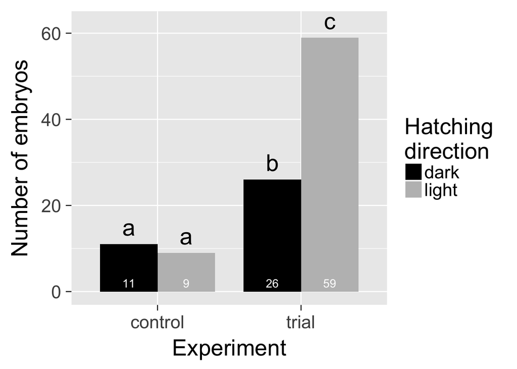

```r
legend_title="Hatching \ndirection" #make legend title here

g = ggplot(data=l, aes(x= experiment, y= count, fill=Hatching.direction)) + #use whole data of yes #1 hatched
  geom_bar(stat="identity", position= "dodge", width = .8) + #group it by cue type with color
  labs(y="Number of embryos", x="Experiment") +
  scale_y_continuous(limits=c(0,62),oob = rescale_none, breaks= pretty_breaks(n=4)) +
  scale_fill_manual(legend_title,values = c("black", "gray")) +
  geom_text(aes(y = c(13, 11, 28, 61), label = c("a", "a", "b", "c")), position = position_dodge(width = .8), color= "black", vjust = 0, size = 8) +
  geom_text(aes(y= c(1, 1, 1, 1), label= l$count), position = position_dodge(width = .8), color= "white", vjust = 0, size = 4) +
  theme_gray(base_size = 22)
g
```